# 机器学习信贷评分卡模型

# Table of Contents

## 1. 信用评分卡模型

- 信用评分卡是衡量信用风险的一种方式，根据客户历史数据，计算评分卡打分，从而量化信用风险，决定是否授信、授信额度等。
- 逻辑回归是构建信用评分卡模型最简单常用的方法。
- 零售信贷业务单笔金额小、案例数量大的特征，使其非常适于通过模型化和自动化的方法提高审批效率。相比之下，企业信贷业务由于缺少足够的数据支持，目前仍然依靠人工审批。
- 评分卡模型的优势：
  1. 提升审批速度，减少人工成本
  2. 审批标准统一、透明，结果容易解读
- 评分卡模型的不足：
  1. 依赖大量数据，存在局限性
- 评分卡模型构建的步骤：
  1. 数据处理
  2. 特征筛选
  3. 模型训练和评估
  4. 使用模型计算结果评分卡构建

## 2. 特征工程

数据来源： LendingClub： 2007-2011 贷款数据：https://www.lendingclub.com/info/download-data.action

数据清洗的任务主要是填充空值，识别并处理异常值。

```python
%%html
<style>
table {float:left}
</style>
```

```python
import numpy as np
import pandas as pd
import matplotlib.pyplot as plt
import seaborn as sns
from pylab import mpl
import matplotlib

%matplotlib inline

sns.set_style('darkgrid')
mpl.rcParams['figure.figsize'] = (8, 5)
```

```python
# 从文件读入原始数据
data = pd.read_csv('data/loan.csv')
data.head()
```

|  | loan_amnt | funded_amnt | funded_amnt_inv | term | int_rate | installment | grade | sub_grade | emp_title | emp_length | ... | policy_code | application_type | acc_now_delinq | chargeoff_within_12_mths | delinq_amnt | pub_rec_bankruptcies | tax_liens | hardship_flag | disbursement_method | debt_settlement_flag |
| --- | --- | --- | --- | --- | --- | --- | --- | --- | --- | --- | --- | --- | --- | --- | --- | --- | --- | --- | --- | --- | --- |
| 0 | 5000.0 | 5000.0 | 4975.0 | 36 months | 10.65% | 162.87 | B | B2 | NaN | 10+ years | ... | 1.0 | Individual | 0.0 | 0.0 | 0.0 | 0.0 | 0.0 | N | Cash | N |
| 1 | 2500.0 | 2500.0 | 2500.0 | 60 months | 15.27% | 59.83 | C | C4 | Ryder | < 1 year | ... | 1.0 | Individual | 0.0 | 0.0 | 0.0 | 0.0 | 0.0 | N | Cash | N |
| 2 | 2400.0 | 2400.0 | 2400.0 | 36 months | 15.96% | 84.33 | C | C5 | NaN | 10+ years | ... | 1.0 | Individual | 0.0 | 0.0 | 0.0 | 0.0 | 0.0 | N | Cash | N |
| 3 | 10000.0 | 10000.0 | 10000.0 | 36 months | 13.49% | 339.31 | C | C1 | AIR RESOURCES BOARD | 10+ years | ... | 1.0 | Individual | 0.0 | 0.0 | 0.0 | 0.0 | 0.0 | N | Cash | N |
| 4 | 3000.0 | 3000.0 | 3000.0 | 60 months | 12.69% | 67.79 | B | B5 | University Medical Group | 1 year | ... | 1.0 | Individual | 0.0 | 0.0 | 0.0 | 0.0 | 0.0 | N | Cash | N |

5 rows × 57 columns

```python
# 初步特征筛选，保留20个对违约预测有帮助的特征
data = data[['loan_amnt','term','int_rate','grade','emp_length','home_ownership','annual_inc','verification_status','purpose','addr_state','dti','inq_last_6mths','open_acc','pub_rec','revol_bal','revol_util','total_acc','chargeoff_within_12_mths','pub_rec_bankruptcies','loan_status']]
data.info()
```

```
<class 'pandas.core.frame.DataFrame'>
RangeIndex: 42535 entries, 0 to 42534
Data columns (total 20 columns):
loan_amnt                   42535 non-null float64
term                        42535 non-null object
int_rate                    42535 non-null object
grade                       42535 non-null object
emp_length                  41423 non-null object
home_ownership              42535 non-null object
annual_inc                  42531 non-null float64
verification_status         42535 non-null object
purpose                     42535 non-null object
addr_state                  42535 non-null object
dti                         42535 non-null float64
inq_last_6mths              42506 non-null float64
open_acc                    42506 non-null float64
pub_rec                     42506 non-null float64
revol_bal                   42535 non-null float64
revol_util                  42445 non-null object
total_acc                   42506 non-null float64
chargeoff_within_12_mths    42390 non-null float64
pub_rec_bankruptcies        41170 non-null float64
loan_status                 42535 non-null object
dtypes: float64(10), object(10)
memory usage: 4.9+ MB
```

### 2.1. 数据清洗

#### 2.1.1. 分类数据清洗

```python
# 观察原始数据中非数值数据的统计描述
data.describe(include=[np.object])
```

|  | term | int_rate | grade | emp_length | home_ownership | verification_status | purpose | addr_state | revol_util | loan_status |
| --- | --- | --- | --- | --- | --- | --- | --- | --- | --- | --- |
| count | 42535 | 42535 | 42535 | 41423 | 42535 | 42535 | 42535 | 42535 | 42445 | 42535 |
| unique | 2 | 394 | 7 | 11 | 5 | 3 | 14 | 50 | 1119 | 4 |
| top | 36 months | 10.99% | B | 10+ years | RENT | Not Verified | debt_consolidation | CA | 0% | Fully Paid |
| freq | 31534 | 970 | 12389 | 9369 | 20181 | 18758 | 19776 | 7429 | 1070 | 34116 |

```python
# 观察 int_rate 和 revol_util 两列数据
data[['int_rate', 'revol_util']].head()
```

|  | int_rate | revol_util |
| --- | --- | --- |
| 0 | 10.65% | 83.7% |
| 1 | 15.27% | 9.4% |
| 2 | 15.96% | 98.5% |
| 3 | 13.49% | 21% |
| 4 | 12.69% | 53.9% |

```python
# 将 int_rate 和 revol_util 两列转化为数值型数据
data[['int_rate', 'revol_util']] = data[['int_rate', 'revol_util']].apply(lambda s: s.str.rstrip('%').astype(float) / 100, axis=1)
```

```python
# 观察原始数据中非数值数据的统计描述
data.describe(include=[np.object])
```

|  | term | grade | emp_length | home_ownership | verification_status | purpose | addr_state | loan_status |
| --- | --- | --- | --- | --- | --- | --- | --- | --- |
| count | 42535 | 42535 | 41423 | 42535 | 42535 | 42535 | 42535 | 42535 |
| unique | 2 | 7 | 11 | 5 | 3 | 14 | 50 | 4 |
| top | 36 months | B | 10+ years | RENT | Not Verified | debt_consolidation | CA | Fully Paid |
| freq | 31534 | 12389 | 9369 | 20181 | 18758 | 19776 | 7429 | 34116 |

```python
# loan_status为预测目标
data.loan_status.unique()
```

```
array(['Fully Paid', 'Charged Off',
       'Does not meet the credit policy. Status:Fully Paid',
       'Does not meet the credit policy. Status:Charged Off'],
      dtype=object)
```

```python
# 将 loan_status 中的数据全部转化为 Fully Paid 或 Charge Off
data['loan_status'] = data.loan_status.map({'Fully Paid':'Fully Paid',  'Charged Off': 'Charged Off',
       'Does not meet the credit policy. Status:Fully Paid': 'Fully Paid',
       'Does not meet the credit policy. Status:Charged Off': 'Charged Off'})
```

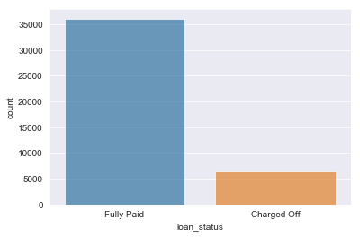

```python
# 观察预测目标数据
sns.countplot(x='loan_status', data=data, alpha=0.7  )
```

```python
# term 数据的类别
data.term.unique()
```

```
array(['36 months', '60 months'], dtype=object)
```

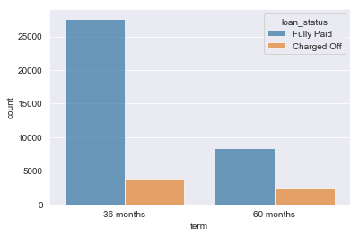

```python
# 观察特征值
sns.countplot(x='term', data=data, alpha=0.7, hue='loan_status')
```

```python
# grade 数据的类别
data.grade.unique()
```

```
array(['B', 'C', 'A', 'E', 'F', 'D', 'G'], dtype=object)
```

```python
from pandas.api.types import CategoricalDtype
# 将 grade 列设置为有序分类数据
data['grade'] = data['grade'].astype(CategoricalDtype(ordered=True))
data.grade.head()
```

```
0    B
1    C
2    C
3    C
4    B
Name: grade, dtype: category
Categories (7, object): [A < B < C < D < E < F < G]
```

```python
# 使用众数填充 emp_length 列
data.emp_length.fillna(data.emp_length.mode()[0], inplace=True)
data.describe(include=[np.object])
```

|  | term | emp_length | home_ownership | verification_status | purpose | addr_state | loan_status |
| --- | --- | --- | --- | --- | --- | --- | --- |
| count | 42535 | 42535 | 42535 | 42535 | 42535 | 42535 | 42535 |
| unique | 2 | 11 | 5 | 3 | 14 | 50 | 2 |
| top | 36 months | 10+ years | RENT | Not Verified | debt_consolidation | CA | Fully Paid |
| freq | 31534 | 10481 | 20181 | 18758 | 19776 | 7429 | 36104 |

```python
# emp_length 数据的类别
data.emp_length.unique()
```

```
array(['10+ years', '< 1 year', '1 year', '3 years', '8 years', '9 years',
       '4 years', '5 years', '6 years', '2 years', '7 years'],
      dtype=object)
```

```python
# 将 emp_length 列设置为有序分类数据
emp_length_dtype = CategoricalDtype(categories=['< 1 year', '1 year', '2 years', '3 years',
       '4 years', '5 years', '6 years', '7 years',  '8 years', '9 years', '10+ years'], ordered=True)
data['emp_length'] = data['emp_length'].astype(emp_length_dtype)
data['emp_length'].head()
```

```
0    10+ years
1     < 1 year
2    10+ years
3    10+ years
4       1 year
Name: emp_length, dtype: category
Categories (11, object): [< 1 year < 1 year < 2 years < 3 years ... 7 years < 8 years < 9 years < 10+ years]
```

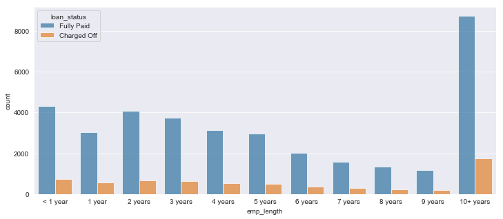

```python
# 观察特征值
plt.figure(figsize=(12, 5))
sns.countplot(x='emp_length', data=data, alpha=0.7, hue='loan_status')
```

```python
# home_ownership 数据的类别
data.home_ownership.unique()
```

```
array(['RENT', 'OWN', 'MORTGAGE', 'OTHER', 'NONE'], dtype=object)
```

```python
# 将 home_ownership 中的 NONE 替换为 OTHER
data['home_ownership'].replace('NONE', 'OTHER', inplace=True)
```

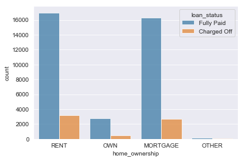

```python
# 观察特征值
sns.countplot(x='home_ownership', data=data, alpha=0.7, hue='loan_status')
plt.show()
```

```python
# verification_status 数据的类别
data.verification_status.unique()
```

```
array(['Verified', 'Source Verified', 'Not Verified'], dtype=object)
```

```python
# 将 verification_status 列设置为有序分类数据
verification_status_dtype = CategoricalDtype(categories=['Verified', 'Source Verified', 'Not Verified'], ordered=True)
data['verification_status'] = data['verification_status'].astype(verification_status_dtype)
data['verification_status'].head()
```

```
0           Verified
1    Source Verified
2       Not Verified
3    Source Verified
4    Source Verified
Name: verification_status, dtype: category
Categories (3, object): [Verified < Source Verified < Not Verified]
```

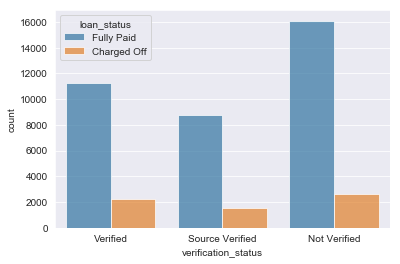

```python
# 观察特征值
sns.countplot(x='verification_status', data=data, alpha=0.7, hue='loan_status')
plt.show()
```

```python
# purpose 数据的类别
data.purpose.unique()
```

```
array(['credit_card', 'car', 'small_business', 'other', 'wedding',
       'debt_consolidation', 'home_improvement', 'major_purchase',
       'medical', 'moving', 'vacation', 'house', 'renewable_energy',
       'educational'], dtype=object)
```

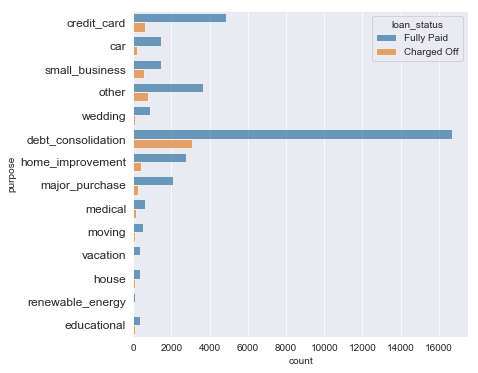

```python
# 观察特征值
plt.figure(figsize=(6, 6))
plt.yticks(fontsize=12)
sns.countplot(y='purpose', data=data, alpha=0.7, hue='loan_status')
```

```python
# addr_state 数据的类别
data.addr_state.unique()
```

```
array(['AZ', 'GA', 'IL', 'CA', 'OR', 'NC', 'TX', 'VA', 'MO', 'CT', 'UT',
       'FL', 'NY', 'PA', 'MN', 'NJ', 'KY', 'OH', 'SC', 'RI', 'LA', 'MA',
       'WA', 'WI', 'AL', 'CO', 'KS', 'NV', 'AK', 'MD', 'WV', 'VT', 'MI',
       'DC', 'SD', 'NH', 'AR', 'NM', 'MT', 'HI', 'WY', 'OK', 'DE', 'MS',
       'TN', 'IA', 'NE', 'ID', 'IN', 'ME'], dtype=object)
```

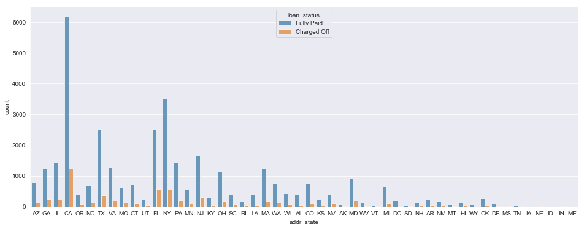

```python
# 观察特征值
plt.figure(figsize=(16,6))
ax = sns.countplot(x='addr_state', data=data, alpha=0.7, hue='loan_status')
```

#### 2.1.2. 数值数据清洗

根据数据的特点对空值进行填充。

```python
# 查看数值数据的空值信息
data.select_dtypes(include=[np.number]).info()
```

```
<class 'pandas.core.frame.DataFrame'>
RangeIndex: 42535 entries, 0 to 42534
Data columns (total 12 columns):
loan_amnt                   42535 non-null float64
int_rate                    42535 non-null float64
annual_inc                  42531 non-null float64
dti                         42535 non-null float64
inq_last_6mths              42506 non-null float64
open_acc                    42506 non-null float64
pub_rec                     42506 non-null float64
revol_bal                   42535 non-null float64
revol_util                  42445 non-null float64
total_acc                   42506 non-null float64
chargeoff_within_12_mths    42390 non-null float64
pub_rec_bankruptcies        41170 non-null float64
dtypes: float64(12)
memory usage: 3.9 MB
```

```python
# 使用众数填充的列
cnt_columns = ['inq_last_6mths', 'open_acc', 'pub_rec', 'total_acc', 'pub_rec_bankruptcies', 'chargeoff_within_12_mths']
# 使用各列中的众数对空值进行填充
data[cnt_columns] = data[cnt_columns].apply(lambda s: s.fillna(s.mode()[0]))
# 使用 annual_inc 列的中位数对空值进行填充
data.annual_inc.fillna(data.annual_inc.quantile(q=0.5), inplace=True)
# 使用 revol_util 列的均值对空值进行填充
data.revol_util.fillna(data.revol_util.mean(), inplace=True)
data.info()
```

```
<class 'pandas.core.frame.DataFrame'>
RangeIndex: 42535 entries, 0 to 42534
Data columns (total 20 columns):
loan_amnt                   42535 non-null float64
term                        42535 non-null object
int_rate                    42535 non-null float64
grade                       42535 non-null category
emp_length                  42535 non-null category
home_ownership              42535 non-null object
annual_inc                  42535 non-null float64
verification_status         42535 non-null category
purpose                     42535 non-null object
addr_state                  42535 non-null object
dti                         42535 non-null float64
inq_last_6mths              42535 non-null float64
open_acc                    42535 non-null float64
pub_rec                     42535 non-null float64
revol_bal                   42535 non-null float64
revol_util                  42535 non-null float64
total_acc                   42535 non-null float64
chargeoff_within_12_mths    42535 non-null float64
pub_rec_bankruptcies        42535 non-null float64
loan_status                 42535 non-null object
dtypes: category(3), float64(12), object(5)
memory usage: 4.8+ MB
```

```python
# 观察计数类数据中唯一值的个数
data[cnt_columns].nunique()
```

```
inq_last_6mths              28
open_acc                    44
pub_rec                      6
total_acc                   83
pub_rec_bankruptcies         3
chargeoff_within_12_mths     1
dtype: int64
```

```python
# 删除 chargeoff_within_12_mths 数据列
data.drop(['chargeoff_within_12_mths'], axis=1, inplace=True)
# 将类别比较少的变量直接转化为非数值类型
data[['pub_rec', 'pub_rec_bankruptcies']] = data[['pub_rec', 'pub_rec_bankruptcies']].astype(str)
data.info()
```

```
<class 'pandas.core.frame.DataFrame'>
RangeIndex: 42535 entries, 0 to 42534
Data columns (total 19 columns):
loan_amnt               42535 non-null float64
term                    42535 non-null object
int_rate                42535 non-null float64
grade                   42535 non-null category
emp_length              42535 non-null category
home_ownership          42535 non-null object
annual_inc              42535 non-null float64
verification_status     42535 non-null category
purpose                 42535 non-null object
addr_state              42535 non-null object
dti                     42535 non-null float64
inq_last_6mths          42535 non-null float64
open_acc                42535 non-null float64
pub_rec                 42535 non-null object
revol_bal               42535 non-null float64
revol_util              42535 non-null float64
total_acc               42535 non-null float64
pub_rec_bankruptcies    42535 non-null object
loan_status             42535 non-null object
dtypes: category(3), float64(9), object(7)
memory usage: 4.2+ MB
```

对数值数据中的离群值进行处理。

```
array([[<matplotlib.axes._subplots.AxesSubplot object at 0x0CD867B0>,
      dtype=object)
```

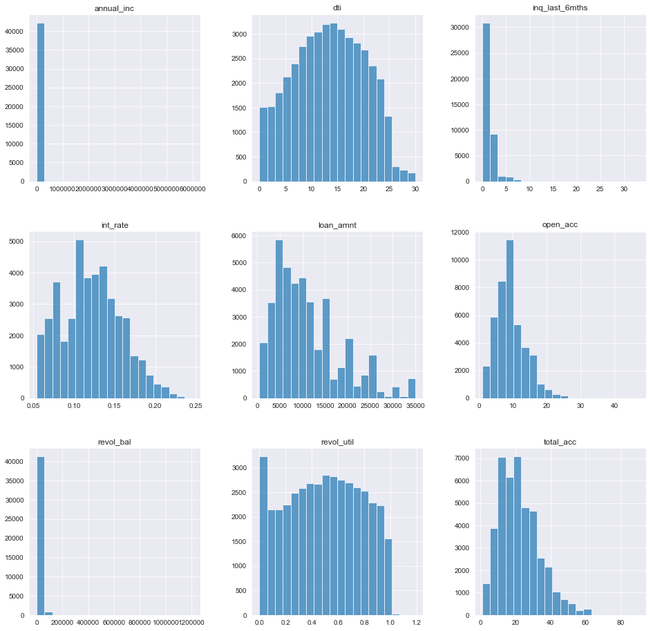

```python
# 观察数值数据分布情况
data.select_dtypes(include=[np.number]).hist(alpha=0.7, figsize=(16,16), bins=20)
```

```python
# 观察 revol_util 中数值大于1的数据
data.revol_util[data.revol_util > 1]
```

```
41517    1.064
41550    1.018
41554    1.043
41592    1.042
41647    1.088
41648    1.061
41697    1.062
41821    1.005
41827    1.014
41890    1.039
41891    1.028
41999    1.007
42058    1.052
42074    1.014
42085    1.065
42130    1.031
42169    1.006
42188    1.027
42205    1.032
42269    1.007
42278    1.015
42303    1.190
42337    1.035
42338    1.014
42346    1.018
42364    1.053
42488    1.057
Name: revol_util, dtype: float64
```

```python
# 可能存在问题的数据列
q_columns =['annual_inc', 'revol_bal']
```

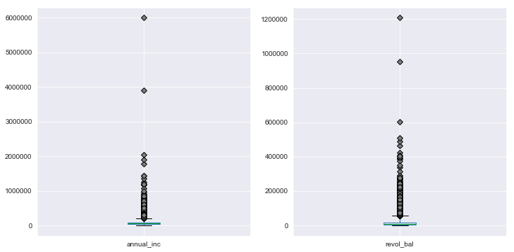

```python
# 观察存疑数据列的 boxplot
fig, axes = plt.subplots(1, 2, figsize=(12,6))

column_ax = zip(q_columns, axes)

for col, ax in column_ax:
    data.boxplot(column=[col], ax=ax, whis=3, flierprops={'marker':'D', 'markerfacecolor':'grey'})
```

```python
# 定义回调函数，去除每列数据中的异常值，异常值为均值两边超过三个标准差的数据
def exclude_extreme(s):
    mean = s.mean()
    sigma = s.std()
    ceiling = mean + 3 * sigma
    floor = mean - 3 * sigma
    s_copy = s.copy()
    s_copy[s_copy > ceiling] = ceiling
    s_copy[s < s_copy] = floor
    return s_copy
```

```python
# 替换制定列的异常值
data.loc[:, ['annual_inc', 'revol_bal']] = data.loc[:, ['annual_inc', 'revol_bal']].apply(exclude_extreme)
```

```
array([[<matplotlib.axes._subplots.AxesSubplot object at 0x0A788210>,
      dtype=object)
```

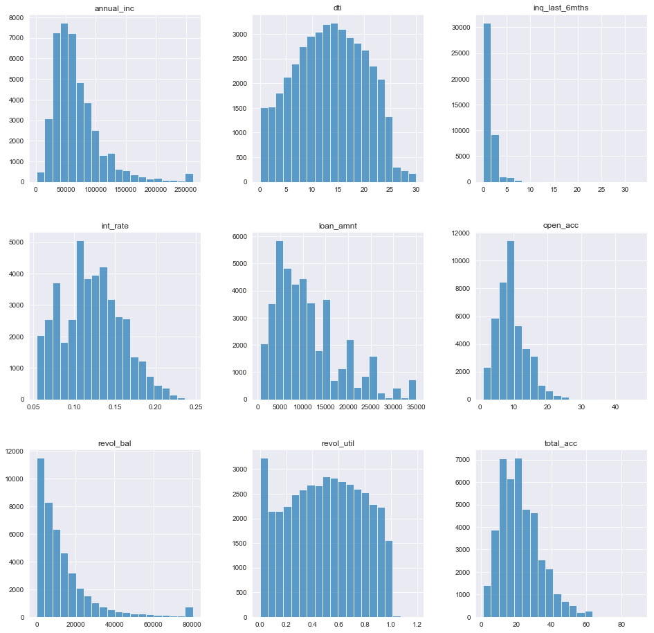

```python
# 观察数值数据分布情况
data.select_dtypes(include=[np.number]).hist(alpha=0.7, figsize=(16,16), bins=20)
```

### 2.2. 数据离散化

- 数据离散化：将数据的值域划分为若干区间。
  - 连续变量离散化
  - 离散变量特征合并
- 数据离散化的意义：
  - 减少连续属性的数量，减少模型的训练时间
  - 方便模型结果的解释与表达
  - 减少偶然波动对模型的影响，一定程度上降低过拟合的风险，加强模型稳定性
- 数据离散化的方法：
  - 无监督离散化：分组过程不考虑数据分类结果
    - 等距离散化
    - 等频离散化
    - 聚类
  - 有监督方法：分组过程考虑数据分组结果
    - 卡方合并：自底向上，合并
    - 基于信息熵的离散化：自顶向下，分割

#### 2.2.1. 使用等距方法对数据离散化

```python
# 计数变量
int_cut = ['inq_last_6mths', 'open_acc', 'pub_rec', 'total_acc', 'pub_rec_bankruptcies', 'dti']

cash = ['annual_inc', 'revol_bal']
```

```python
# 定义对连续变量进行等距离散化的回调函数
def apply_func_discrete(s):
    cut_precision = 2
    if s.name in int_cut:   # 对于计数类的变量，分组边界设置为整数
        cut_precision = 0
    elif s.name in cash:    # 对于大额金额变量，分组边界设置为100的整数倍
        cut_precision = -2
    return pd.cut(s, 10, duplicates='drop', precision=cut_precision)
```

```python
# 将数值数据离散化
data_num = data.select_dtypes(include=[np.number]).apply(apply_func_discrete)
data_num.head()
```

|  | loan_amnt | int_rate | annual_inc | dti | inq_last_6mths | open_acc | revol_bal | revol_util | total_acc |
| --- | --- | --- | --- | --- | --- | --- | --- | --- | --- |
| 0 | (3950.0, 7400.0] | (0.093, 0.11] | (1600.0, 27800.0] | (27.0, 30.0] | (-0.0, 3.0] | (1.0, 6.0] | (8000.0, 16100.0] | (0.83, 0.95] | (1.0, 10.0] |
| 1 | (465.5, 3950.0] | (0.15, 0.17] | (27800.0, 53800.0] | (-0.0, 3.0] | (3.0, 7.0] | (1.0, 6.0] | (-100.0, 8000.0] | (-0.0012, 0.12] | (1.0, 10.0] |
| 2 | (465.5, 3950.0] | (0.15, 0.17] | (1600.0, 27800.0] | (6.0, 9.0] | (-0.0, 3.0] | (1.0, 6.0] | (-100.0, 8000.0] | (0.95, 1.07] | (10.0, 19.0] |
| 3 | (7400.0, 10850.0] | (0.13, 0.15] | (27800.0, 53800.0] | (18.0, 21.0] | (-0.0, 3.0] | (6.0, 10.0] | (-100.0, 8000.0] | (0.12, 0.24] | (37.0, 46.0] |
| 4 | (465.5, 3950.0] | (0.11, 0.13] | (79800.0, 105700.0] | (15.0, 18.0] | (-0.0, 3.0] | (15.0, 19.0] | (24100.0, 32100.0] | (0.48, 0.6] | (37.0, 46.0] |

```python
# 使用离散数据代替原来的连续数据
data_labeled = pd.concat([data.select_dtypes(exclude=[np.number]), data_num], axis=1)
```

```python
# 观察数据离散化以后的唯一值统计
data_labeled.apply(lambda s: s.nunique())
```

```
term                     2
grade                    7
emp_length              11
home_ownership           4
verification_status      3
purpose                 14
addr_state              50
pub_rec                  6
pub_rec_bankruptcies     3
loan_status              2
loan_amnt               10
int_rate                10
annual_inc              10
dti                     10
inq_last_6mths          10
open_acc                10
revol_bal               10
revol_util              10
total_acc               10
dtype: int64
```

```python
data_labeled.info()
```

```
<class 'pandas.core.frame.DataFrame'>
RangeIndex: 42535 entries, 0 to 42534
Data columns (total 19 columns):
term                    42535 non-null object
grade                   42535 non-null category
emp_length              42535 non-null category
home_ownership          42535 non-null object
verification_status     42535 non-null category
purpose                 42535 non-null object
addr_state              42535 non-null object
pub_rec                 42535 non-null object
pub_rec_bankruptcies    42535 non-null object
loan_status             42535 non-null object
loan_amnt               42535 non-null category
int_rate                42535 non-null category
annual_inc              42535 non-null category
dti                     42535 non-null category
inq_last_6mths          42535 non-null category
open_acc                42535 non-null category
revol_bal               42535 non-null category
revol_util              42535 non-null category
total_acc               42535 non-null category
dtypes: category(12), object(7)
memory usage: 1.6+ MB
```

```python
data_labeled.dti.head()
```

```
0    (27.0, 30.0]
1     (-0.0, 3.0]
2      (6.0, 9.0]
3    (18.0, 21.0]
4    (15.0, 18.0]
Name: dti, dtype: category
Categories (10, interval[float64]): [(-0.0, 3.0] < (3.0, 6.0] < (6.0, 9.0] < (9.0, 12.0] ... (18.0, 21.0] < (21.0, 24.0] < (24.0, 27.0] < (27.0, 30.0]]
```

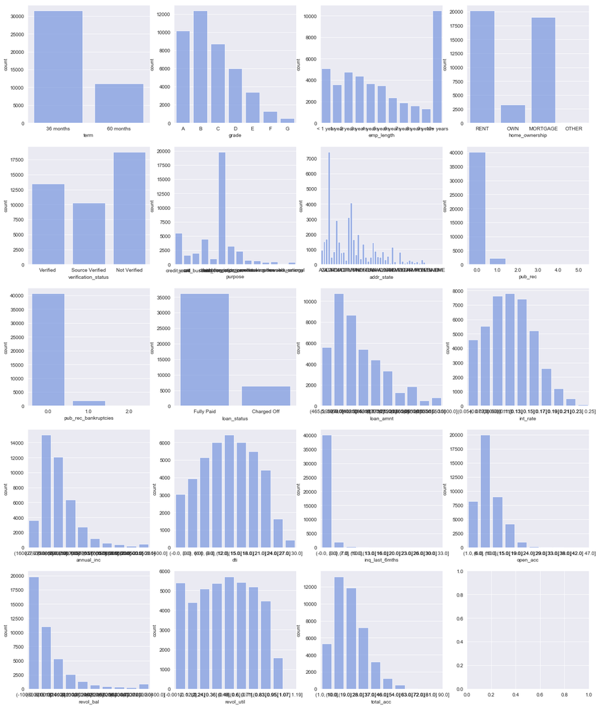

```python
# 观察数值数据分布情况
fig, axes = plt.subplots(5, 4, figsize=(20,25))

column_ax = zip(data_labeled, axes.flatten())

for col, ax in column_ax:
    sns.countplot(x=col, data=data_labeled, ax=ax, color='#6890F0', alpha=0.7)
```

#### 2.2.2. 合并样本量不足的分组

统计每个分组内的样本数量，将样本量不足30个的分组合并到其他分组中。

```python
def count_samples(df, col: str):
    """
    统计df中col列里各分组的样本数量，返回统计结果的DataFrame
    param df: 原始数据，每列为一个特征
    param col：df 中的列名称
    return：返回统计结果的DataFrame
    """
    data = pd.DataFrame(df.groupby(col)[col].count()).rename({col: 'n_samples'}, axis=1)
    data['column'] = col
    return data
```

```python
# 测试 count_samples() 函数
count_samples(data_labeled, 'dti')
```

| dti | n_samples | column |
| --- | --- | --- |
| (-0.0, 3.0] | 3036 | dti |
| (3.0, 6.0] | 3941 | dti |
| (6.0, 9.0] | 5145 | dti |
| (9.0, 12.0] | 5997 | dti |
| (12.0, 15.0] | 6429 | dti |
| (15.0, 18.0] | 6022 | dti |
| (18.0, 21.0] | 5485 | dti |
| (21.0, 24.0] | 4433 | dti |
| (24.0, 27.0] | 1630 | dti |
| (27.0, 30.0] | 417 | dti |

```python
# 统计所有原始分组的样本数量
count_df = pd.concat([count_samples(data_labeled, col) for col in data_labeled]).reset_index().rename({'index': 'group'}, axis=1)
count_df
```

|  | group | n_samples | column |
| --- | --- | --- | --- |
| 0 | 36 months | 31534 | term |
| 1 | 60 months | 11001 | term |
| 2 | A | 10183 | grade |
| 3 | B | 12389 | grade |
| 4 | C | 8740 | grade |
| 5 | D | 6016 | grade |
| 6 | E | 3394 | grade |
| 7 | F | 1301 | grade |
| 8 | G | 512 | grade |
| 9 | < 1 year | 5062 | emp_length |
| 10 | 1 year | 3595 | emp_length |
| 11 | 2 years | 4743 | emp_length |
| 12 | 3 years | 4364 | emp_length |
| 13 | 4 years | 3649 | emp_length |
| 14 | 5 years | 3458 | emp_length |
| 15 | 6 years | 2375 | emp_length |
| 16 | 7 years | 1875 | emp_length |
| 17 | 8 years | 1592 | emp_length |
| 18 | 9 years | 1341 | emp_length |
| 19 | 10+ years | 10481 | emp_length |
| 20 | MORTGAGE | 18959 | home_ownership |
| 21 | OTHER | 144 | home_ownership |
| 22 | OWN | 3251 | home_ownership |
| 23 | RENT | 20181 | home_ownership |
| 24 | Verified | 13471 | verification_status |
| 25 | Source Verified | 10306 | verification_status |
| 26 | Not Verified | 18758 | verification_status |
| 27 | car | 1615 | purpose |
| 28 | credit_card | 5477 | purpose |
| 29 | debt_consolidation | 19776 | purpose |
| ... | ... | ... | ... |
| 162 | (-100.0, 8000.0] | 19843 | revol_bal |
| 163 | (8000.0, 16100.0] | 10995 | revol_bal |
| 164 | (16100.0, 24100.0] | 5284 | revol_bal |
| 165 | (24100.0, 32100.0] | 2566 | revol_bal |
| 166 | (32100.0, 40200.0] | 1278 | revol_bal |
| 167 | (40200.0, 48200.0] | 738 | revol_bal |
| 168 | (48200.0, 56200.0] | 454 | revol_bal |
| 169 | (56200.0, 64300.0] | 305 | revol_bal |
| 170 | (64300.0, 72300.0] | 220 | revol_bal |
| 171 | (72300.0, 80400.0] | 852 | revol_bal |
| 172 | (-0.0012, 0.12] | 5383 | revol_util |
| 173 | (0.12, 0.24] | 4395 | revol_util |
| 174 | (0.24, 0.36] | 5072 | revol_util |
| 175 | (0.36, 0.48] | 5356 | revol_util |
| 176 | (0.48, 0.6] | 5706 | revol_util |
| 177 | (0.6, 0.71] | 5406 | revol_util |
| 178 | (0.71, 0.83] | 5173 | revol_util |
| 179 | (0.83, 0.95] | 4461 | revol_util |
| 180 | (0.95, 1.07] | 1581 | revol_util |
| 181 | (1.07, 1.19] | 2 | revol_util |
| 182 | (1.0, 10.0] | 5283 | total_acc |
| 183 | (10.0, 19.0] | 13200 | total_acc |
| 184 | (19.0, 28.0] | 11896 | total_acc |
| 185 | (28.0, 37.0] | 7211 | total_acc |
| 186 | (37.0, 46.0] | 3189 | total_acc |
| 187 | (46.0, 54.0] | 1228 | total_acc |
| 188 | (54.0, 63.0] | 486 | total_acc |
| 189 | (63.0, 72.0] | 26 | total_acc |
| 190 | (72.0, 81.0] | 14 | total_acc |
| 191 | (81.0, 90.0] | 2 | total_acc |

192 rows × 3 columns

```python
# 标记样本量不足30个的分组
count_df['merge_mark'] = np.where(count_df.n_samples < 30, 0, 1)
count_df
```

|  | group | n_samples | column | merge_mark |
| --- | --- | --- | --- | --- |
| 0 | 36 months | 31534 | term | 1 |
| 1 | 60 months | 11001 | term | 1 |
| 2 | A | 10183 | grade | 1 |
| 3 | B | 12389 | grade | 1 |
| 4 | C | 8740 | grade | 1 |
| 5 | D | 6016 | grade | 1 |
| 6 | E | 3394 | grade | 1 |
| 7 | F | 1301 | grade | 1 |
| 8 | G | 512 | grade | 1 |
| 9 | < 1 year | 5062 | emp_length | 1 |
| 10 | 1 year | 3595 | emp_length | 1 |
| 11 | 2 years | 4743 | emp_length | 1 |
| 12 | 3 years | 4364 | emp_length | 1 |
| 13 | 4 years | 3649 | emp_length | 1 |
| 14 | 5 years | 3458 | emp_length | 1 |
| 15 | 6 years | 2375 | emp_length | 1 |
| 16 | 7 years | 1875 | emp_length | 1 |
| 17 | 8 years | 1592 | emp_length | 1 |
| 18 | 9 years | 1341 | emp_length | 1 |
| 19 | 10+ years | 10481 | emp_length | 1 |
| 20 | MORTGAGE | 18959 | home_ownership | 1 |
| 21 | OTHER | 144 | home_ownership | 1 |
| 22 | OWN | 3251 | home_ownership | 1 |
| 23 | RENT | 20181 | home_ownership | 1 |
| 24 | Verified | 13471 | verification_status | 1 |
| 25 | Source Verified | 10306 | verification_status | 1 |
| 26 | Not Verified | 18758 | verification_status | 1 |
| 27 | car | 1615 | purpose | 1 |
| 28 | credit_card | 5477 | purpose | 1 |
| 29 | debt_consolidation | 19776 | purpose | 1 |
| ... | ... | ... | ... | ... |
| 162 | (-100.0, 8000.0] | 19843 | revol_bal | 1 |
| 163 | (8000.0, 16100.0] | 10995 | revol_bal | 1 |
| 164 | (16100.0, 24100.0] | 5284 | revol_bal | 1 |
| 165 | (24100.0, 32100.0] | 2566 | revol_bal | 1 |
| 166 | (32100.0, 40200.0] | 1278 | revol_bal | 1 |
| 167 | (40200.0, 48200.0] | 738 | revol_bal | 1 |
| 168 | (48200.0, 56200.0] | 454 | revol_bal | 1 |
| 169 | (56200.0, 64300.0] | 305 | revol_bal | 1 |
| 170 | (64300.0, 72300.0] | 220 | revol_bal | 1 |
| 171 | (72300.0, 80400.0] | 852 | revol_bal | 1 |
| 172 | (-0.0012, 0.12] | 5383 | revol_util | 1 |
| 173 | (0.12, 0.24] | 4395 | revol_util | 1 |
| 174 | (0.24, 0.36] | 5072 | revol_util | 1 |
| 175 | (0.36, 0.48] | 5356 | revol_util | 1 |
| 176 | (0.48, 0.6] | 5706 | revol_util | 1 |
| 177 | (0.6, 0.71] | 5406 | revol_util | 1 |
| 178 | (0.71, 0.83] | 5173 | revol_util | 1 |
| 179 | (0.83, 0.95] | 4461 | revol_util | 1 |
| 180 | (0.95, 1.07] | 1581 | revol_util | 1 |
| 181 | (1.07, 1.19] | 2 | revol_util | 0 |
| 182 | (1.0, 10.0] | 5283 | total_acc | 1 |
| 183 | (10.0, 19.0] | 13200 | total_acc | 1 |
| 184 | (19.0, 28.0] | 11896 | total_acc | 1 |
| 185 | (28.0, 37.0] | 7211 | total_acc | 1 |
| 186 | (37.0, 46.0] | 3189 | total_acc | 1 |
| 187 | (46.0, 54.0] | 1228 | total_acc | 1 |
| 188 | (54.0, 63.0] | 486 | total_acc | 1 |
| 189 | (63.0, 72.0] | 26 | total_acc | 0 |
| 190 | (72.0, 81.0] | 14 | total_acc | 0 |
| 191 | (81.0, 90.0] | 2 | total_acc | 0 |

192 rows × 4 columns

```python
def order_df(df, sort_col):
    """
    根据特征变量属于有序特征或无序特征对df进行排序，对于无序变量，根据分组内部的样本数量对分组进行排序；
    对有序变量，根据数据的索引顺序（与分组的顺序相同）对分组进行排序
    param df: 需要排序的数据表
    param col: 对于无序数据，作为排序标准的列名称
    return：返回根据排序规则排序后的数据表
    """
    unordered_cols = ['home_ownership', 'purpose', 'addr_state']
    df_copy = df.copy()
    col = df_copy['column'].iloc[0]

    if col in unordered_cols:
        return df_copy.sort_values(sort_col, ascending=False)
    else:
        return df_copy.sort_index()
```

```python
def group_merge_mark(df, sort_col):
    """
    apply函数的回调函数，对相同特征变量的分组进行处理，对无序变量，根据样本数量降序排序后对merge_mark累计求和，产生特征变量的分组编号；
    对有序变量，根据原始索引对df进行升序排序后对merge_mark累计求和，产生特征变量的分组编号；
    param df：属于同一特征变量的数据
    return：返回包含merge_group数据的Series
    """
    df_ordered = order_df(df, sort_col)
    df_ordered['merge_group'] = df_ordered.column + '_' + df_ordered.merge_mark.cumsum().astype(str)
    return df_ordered.merge_group
```

```python
# 分组计算 count_df 中每条数据的 merge_group
count_df['merge_group'] = count_df.groupby('column', group_keys=False).apply(group_merge_mark, sort_col='n_samples')
count_df
```

|  | group | n_samples | column | merge_mark | merge_group |
| --- | --- | --- | --- | --- | --- |
| 0 | 36 months | 31534 | term | 1 | term_1 |
| 1 | 60 months | 11001 | term | 1 | term_2 |
| 2 | A | 10183 | grade | 1 | grade_1 |
| 3 | B | 12389 | grade | 1 | grade_2 |
| 4 | C | 8740 | grade | 1 | grade_3 |
| 5 | D | 6016 | grade | 1 | grade_4 |
| 6 | E | 3394 | grade | 1 | grade_5 |
| 7 | F | 1301 | grade | 1 | grade_6 |
| 8 | G | 512 | grade | 1 | grade_7 |
| 9 | < 1 year | 5062 | emp_length | 1 | emp_length_1 |
| 10 | 1 year | 3595 | emp_length | 1 | emp_length_2 |
| 11 | 2 years | 4743 | emp_length | 1 | emp_length_3 |
| 12 | 3 years | 4364 | emp_length | 1 | emp_length_4 |
| 13 | 4 years | 3649 | emp_length | 1 | emp_length_5 |
| 14 | 5 years | 3458 | emp_length | 1 | emp_length_6 |
| 15 | 6 years | 2375 | emp_length | 1 | emp_length_7 |
| 16 | 7 years | 1875 | emp_length | 1 | emp_length_8 |
| 17 | 8 years | 1592 | emp_length | 1 | emp_length_9 |
| 18 | 9 years | 1341 | emp_length | 1 | emp_length_10 |
| 19 | 10+ years | 10481 | emp_length | 1 | emp_length_11 |
| 20 | MORTGAGE | 18959 | home_ownership | 1 | home_ownership_2 |
| 21 | OTHER | 144 | home_ownership | 1 | home_ownership_4 |
| 22 | OWN | 3251 | home_ownership | 1 | home_ownership_3 |
| 23 | RENT | 20181 | home_ownership | 1 | home_ownership_1 |
| 24 | Verified | 13471 | verification_status | 1 | verification_status_1 |
| 25 | Source Verified | 10306 | verification_status | 1 | verification_status_2 |
| 26 | Not Verified | 18758 | verification_status | 1 | verification_status_3 |
| 27 | car | 1615 | purpose | 1 | purpose_7 |
| 28 | credit_card | 5477 | purpose | 1 | purpose_2 |
| 29 | debt_consolidation | 19776 | purpose | 1 | purpose_1 |
| ... | ... | ... | ... | ... | ... |
| 162 | (-100.0, 8000.0] | 19843 | revol_bal | 1 | revol_bal_1 |
| 163 | (8000.0, 16100.0] | 10995 | revol_bal | 1 | revol_bal_2 |
| 164 | (16100.0, 24100.0] | 5284 | revol_bal | 1 | revol_bal_3 |
| 165 | (24100.0, 32100.0] | 2566 | revol_bal | 1 | revol_bal_4 |
| 166 | (32100.0, 40200.0] | 1278 | revol_bal | 1 | revol_bal_5 |
| 167 | (40200.0, 48200.0] | 738 | revol_bal | 1 | revol_bal_6 |
| 168 | (48200.0, 56200.0] | 454 | revol_bal | 1 | revol_bal_7 |
| 169 | (56200.0, 64300.0] | 305 | revol_bal | 1 | revol_bal_8 |
| 170 | (64300.0, 72300.0] | 220 | revol_bal | 1 | revol_bal_9 |
| 171 | (72300.0, 80400.0] | 852 | revol_bal | 1 | revol_bal_10 |
| 172 | (-0.0012, 0.12] | 5383 | revol_util | 1 | revol_util_1 |
| 173 | (0.12, 0.24] | 4395 | revol_util | 1 | revol_util_2 |
| 174 | (0.24, 0.36] | 5072 | revol_util | 1 | revol_util_3 |
| 175 | (0.36, 0.48] | 5356 | revol_util | 1 | revol_util_4 |
| 176 | (0.48, 0.6] | 5706 | revol_util | 1 | revol_util_5 |
| 177 | (0.6, 0.71] | 5406 | revol_util | 1 | revol_util_6 |
| 178 | (0.71, 0.83] | 5173 | revol_util | 1 | revol_util_7 |
| 179 | (0.83, 0.95] | 4461 | revol_util | 1 | revol_util_8 |
| 180 | (0.95, 1.07] | 1581 | revol_util | 1 | revol_util_9 |
| 181 | (1.07, 1.19] | 2 | revol_util | 0 | revol_util_9 |
| 182 | (1.0, 10.0] | 5283 | total_acc | 1 | total_acc_1 |
| 183 | (10.0, 19.0] | 13200 | total_acc | 1 | total_acc_2 |
| 184 | (19.0, 28.0] | 11896 | total_acc | 1 | total_acc_3 |
| 185 | (28.0, 37.0] | 7211 | total_acc | 1 | total_acc_4 |
| 186 | (37.0, 46.0] | 3189 | total_acc | 1 | total_acc_5 |
| 187 | (46.0, 54.0] | 1228 | total_acc | 1 | total_acc_6 |
| 188 | (54.0, 63.0] | 486 | total_acc | 1 | total_acc_7 |
| 189 | (63.0, 72.0] | 26 | total_acc | 0 | total_acc_7 |
| 190 | (72.0, 81.0] | 14 | total_acc | 0 | total_acc_7 |
| 191 | (81.0, 90.0] | 2 | total_acc | 0 | total_acc_7 |

192 rows × 5 columns

```python
# 检查 merge_group 标记是否正确
count_df[count_df.column == 'total_acc']
```

|  | group | n_samples | column | merge_mark | merge_group |
| --- | --- | --- | --- | --- | --- |
| 182 | (1.0, 10.0] | 5283 | total_acc | 1 | total_acc_1 |
| 183 | (10.0, 19.0] | 13200 | total_acc | 1 | total_acc_2 |
| 184 | (19.0, 28.0] | 11896 | total_acc | 1 | total_acc_3 |
| 185 | (28.0, 37.0] | 7211 | total_acc | 1 | total_acc_4 |
| 186 | (37.0, 46.0] | 3189 | total_acc | 1 | total_acc_5 |
| 187 | (46.0, 54.0] | 1228 | total_acc | 1 | total_acc_6 |
| 188 | (54.0, 63.0] | 486 | total_acc | 1 | total_acc_7 |
| 189 | (63.0, 72.0] | 26 | total_acc | 0 | total_acc_7 |
| 190 | (72.0, 81.0] | 14 | total_acc | 0 | total_acc_7 |
| 191 | (81.0, 90.0] | 2 | total_acc | 0 | total_acc_7 |

```python
# 观察所有需要合并的分组是否标记正确
count_df[count_df.merge_mark == 0]
```

|  | group | n_samples | column | merge_mark | merge_group |
| --- | --- | --- | --- | --- | --- |
| 53 | IA | 12 | addr_state | 0 | addr_state_44 |
| 54 | ID | 9 | addr_state | 0 | addr_state_44 |
| 56 | IN | 19 | addr_state | 0 | addr_state_44 |
| 62 | ME | 3 | addr_state | 0 | addr_state_44 |
| 66 | MS | 26 | addr_state | 0 | addr_state_44 |
| 69 | NE | 11 | addr_state | 0 | addr_state_44 |
| 94 | 3.0 | 11 | pub_rec | 0 | pub_rec_3 |
| 95 | 4.0 | 2 | pub_rec | 0 | pub_rec_3 |
| 96 | 5.0 | 1 | pub_rec | 0 | pub_rec_3 |
| 99 | 2.0 | 8 | pub_rec_bankruptcies | 0 | pub_rec_bankruptcies_2 |
| 146 | (13.0, 16.0] | 18 | inq_last_6mths | 0 | inq_last_6mths_4 |
| 147 | (16.0, 20.0] | 8 | inq_last_6mths | 0 | inq_last_6mths_4 |
| 148 | (20.0, 23.0] | 1 | inq_last_6mths | 0 | inq_last_6mths_4 |
| 149 | (23.0, 26.0] | 3 | inq_last_6mths | 0 | inq_last_6mths_4 |
| 150 | (26.0, 30.0] | 2 | inq_last_6mths | 0 | inq_last_6mths_4 |
| 151 | (30.0, 33.0] | 3 | inq_last_6mths | 0 | inq_last_6mths_4 |
| 159 | (33.0, 38.0] | 15 | open_acc | 0 | open_acc_7 |
| 160 | (38.0, 42.0] | 5 | open_acc | 0 | open_acc_7 |
| 161 | (42.0, 47.0] | 3 | open_acc | 0 | open_acc_7 |
| 181 | (1.07, 1.19] | 2 | revol_util | 0 | revol_util_9 |
| 189 | (63.0, 72.0] | 26 | total_acc | 0 | total_acc_7 |
| 190 | (72.0, 81.0] | 14 | total_acc | 0 | total_acc_7 |
| 191 | (81.0, 90.0] | 2 | total_acc | 0 | total_acc_7 |

```python
def merge_interval(interval_list):
    """
    合并 interval_list 中的区间为一个大区间
    param interval_list: 列表，其中元素为interval类型数据
    """
    left, right = zip(*[(itv.left, itv.right) for itv in interval_list])
    return pd.Interval(min(left), max(right))
```

```python
# 定义一个测试 interval 列表
test_list = pd.interval_range(0, 5)
test_list
```

```
IntervalIndex([(0, 1], (1, 2], (2, 3], (3, 4], (4, 5]]
              closed='right',
              dtype='interval[int64]')
```

```python
# 测试 merge_interval 函数
merge_interval(test_list)
```

```
Interval(0, 5, closed='right')
```

```python
def get_group(s):
    """
    根据传入的Series数据计算合并分组以后的分组值
    param s: 需要合并的分组标签组成的 Series
    return：返回合并以后的分组标签
    """
    if type(s.iloc[0]) == pd._libs.interval.Interval:
        group = merge_interval(s)
    else:
        group = '/'.join(s.astype(str))
    return group
```

```python
# 测试 get_group() 函数
tmp = count_df[count_df.merge_group == 'total_acc_7']
get_group(tmp.group)
```

```
Interval(54.0, 90.0, closed='right')
```

```python
def get_merged_group(df):
    """
    作为回调函数使用，合并df中 merge_group 列相同的行的数据，返回数据合并以后的结果
    param df: 包含 merge_group 分组的数据
    return：返回数据合并以后的数据
    """
    if len(df) == 1:    # 如果分组中只有一条数据，即不需要合并，返回传入的数据
        return df.group
    else:
        group = get_group(df.group)
        s = pd.Series(group, index=df.index)
        return s
```

```python
# 使用 get_merged_group() 函数计算合并后的分组标签
count_df['merged_label'] = count_df.groupby('merge_group', group_keys=False).apply(get_merged_group)
count_df
```

|  | group | n_samples | column | merge_mark | merge_group | merged_label |
| --- | --- | --- | --- | --- | --- | --- |
| 0 | 36 months | 31534 | term | 1 | term_1 | 36 months |
| 1 | 60 months | 11001 | term | 1 | term_2 | 60 months |
| 2 | A | 10183 | grade | 1 | grade_1 | A |
| 3 | B | 12389 | grade | 1 | grade_2 | B |
| 4 | C | 8740 | grade | 1 | grade_3 | C |
| 5 | D | 6016 | grade | 1 | grade_4 | D |
| 6 | E | 3394 | grade | 1 | grade_5 | E |
| 7 | F | 1301 | grade | 1 | grade_6 | F |
| 8 | G | 512 | grade | 1 | grade_7 | G |
| 9 | < 1 year | 5062 | emp_length | 1 | emp_length_1 | < 1 year |
| 10 | 1 year | 3595 | emp_length | 1 | emp_length_2 | 1 year |
| 11 | 2 years | 4743 | emp_length | 1 | emp_length_3 | 2 years |
| 12 | 3 years | 4364 | emp_length | 1 | emp_length_4 | 3 years |
| 13 | 4 years | 3649 | emp_length | 1 | emp_length_5 | 4 years |
| 14 | 5 years | 3458 | emp_length | 1 | emp_length_6 | 5 years |
| 15 | 6 years | 2375 | emp_length | 1 | emp_length_7 | 6 years |
| 16 | 7 years | 1875 | emp_length | 1 | emp_length_8 | 7 years |
| 17 | 8 years | 1592 | emp_length | 1 | emp_length_9 | 8 years |
| 18 | 9 years | 1341 | emp_length | 1 | emp_length_10 | 9 years |
| 19 | 10+ years | 10481 | emp_length | 1 | emp_length_11 | 10+ years |
| 20 | MORTGAGE | 18959 | home_ownership | 1 | home_ownership_2 | MORTGAGE |
| 21 | OTHER | 144 | home_ownership | 1 | home_ownership_4 | OTHER |
| 22 | OWN | 3251 | home_ownership | 1 | home_ownership_3 | OWN |
| 23 | RENT | 20181 | home_ownership | 1 | home_ownership_1 | RENT |
| 24 | Verified | 13471 | verification_status | 1 | verification_status_1 | Verified |
| 25 | Source Verified | 10306 | verification_status | 1 | verification_status_2 | Source Verified |
| 26 | Not Verified | 18758 | verification_status | 1 | verification_status_3 | Not Verified |
| 27 | car | 1615 | purpose | 1 | purpose_7 | car |
| 28 | credit_card | 5477 | purpose | 1 | purpose_2 | credit_card |
| 29 | debt_consolidation | 19776 | purpose | 1 | purpose_1 | debt_consolidation |
| ... | ... | ... | ... | ... | ... | ... |
| 162 | (-100.0, 8000.0] | 19843 | revol_bal | 1 | revol_bal_1 | (-100.0, 8000.0] |
| 163 | (8000.0, 16100.0] | 10995 | revol_bal | 1 | revol_bal_2 | (8000.0, 16100.0] |
| 164 | (16100.0, 24100.0] | 5284 | revol_bal | 1 | revol_bal_3 | (16100.0, 24100.0] |
| 165 | (24100.0, 32100.0] | 2566 | revol_bal | 1 | revol_bal_4 | (24100.0, 32100.0] |
| 166 | (32100.0, 40200.0] | 1278 | revol_bal | 1 | revol_bal_5 | (32100.0, 40200.0] |
| 167 | (40200.0, 48200.0] | 738 | revol_bal | 1 | revol_bal_6 | (40200.0, 48200.0] |
| 168 | (48200.0, 56200.0] | 454 | revol_bal | 1 | revol_bal_7 | (48200.0, 56200.0] |
| 169 | (56200.0, 64300.0] | 305 | revol_bal | 1 | revol_bal_8 | (56200.0, 64300.0] |
| 170 | (64300.0, 72300.0] | 220 | revol_bal | 1 | revol_bal_9 | (64300.0, 72300.0] |
| 171 | (72300.0, 80400.0] | 852 | revol_bal | 1 | revol_bal_10 | (72300.0, 80400.0] |
| 172 | (-0.0012, 0.12] | 5383 | revol_util | 1 | revol_util_1 | (-0.0012, 0.12] |
| 173 | (0.12, 0.24] | 4395 | revol_util | 1 | revol_util_2 | (0.12, 0.24] |
| 174 | (0.24, 0.36] | 5072 | revol_util | 1 | revol_util_3 | (0.24, 0.36] |
| 175 | (0.36, 0.48] | 5356 | revol_util | 1 | revol_util_4 | (0.36, 0.48] |
| 176 | (0.48, 0.6] | 5706 | revol_util | 1 | revol_util_5 | (0.48, 0.6] |
| 177 | (0.6, 0.71] | 5406 | revol_util | 1 | revol_util_6 | (0.6, 0.71] |
| 178 | (0.71, 0.83] | 5173 | revol_util | 1 | revol_util_7 | (0.71, 0.83] |
| 179 | (0.83, 0.95] | 4461 | revol_util | 1 | revol_util_8 | (0.83, 0.95] |
| 180 | (0.95, 1.07] | 1581 | revol_util | 1 | revol_util_9 | (0.95, 1.19] |
| 181 | (1.07, 1.19] | 2 | revol_util | 0 | revol_util_9 | (0.95, 1.19] |
| 182 | (1.0, 10.0] | 5283 | total_acc | 1 | total_acc_1 | (1.0, 10.0] |
| 183 | (10.0, 19.0] | 13200 | total_acc | 1 | total_acc_2 | (10.0, 19.0] |
| 184 | (19.0, 28.0] | 11896 | total_acc | 1 | total_acc_3 | (19.0, 28.0] |
| 185 | (28.0, 37.0] | 7211 | total_acc | 1 | total_acc_4 | (28.0, 37.0] |
| 186 | (37.0, 46.0] | 3189 | total_acc | 1 | total_acc_5 | (37.0, 46.0] |
| 187 | (46.0, 54.0] | 1228 | total_acc | 1 | total_acc_6 | (46.0, 54.0] |
| 188 | (54.0, 63.0] | 486 | total_acc | 1 | total_acc_7 | (54.0, 90.0] |
| 189 | (63.0, 72.0] | 26 | total_acc | 0 | total_acc_7 | (54.0, 90.0] |
| 190 | (72.0, 81.0] | 14 | total_acc | 0 | total_acc_7 | (54.0, 90.0] |
| 191 | (81.0, 90.0] | 2 | total_acc | 0 | total_acc_7 | (54.0, 90.0] |

192 rows × 6 columns

```python
def get_single_map(df):
    """
    计算单一特征变量的分组标签映射表，作为groupby的回调函数使用
    param df：count_df的子表，按照merge_group列汇总的结果
    return：返回以需要合并的group标签为索引的DataFrame，值为合并后的标签和数据所属的特征变量名称
    """
    if len(df) == 1:
        return None
    else:
        return df.loc[:, ['group', 'column', 'merged_label']].set_index('group')
```

```python
# 获取所有被合并的分组合并以后的标签映射关系
group_map = count_df.groupby('merge_group', group_keys=False).apply(get_single_map)
group_map
```

| group | column | merged_label |
| --- | --- | --- |
| IA | addr_state | IA/ID/IN/ME/MS/NE/TN |
| ID | addr_state | IA/ID/IN/ME/MS/NE/TN |
| IN | addr_state | IA/ID/IN/ME/MS/NE/TN |
| ME | addr_state | IA/ID/IN/ME/MS/NE/TN |
| MS | addr_state | IA/ID/IN/ME/MS/NE/TN |
| NE | addr_state | IA/ID/IN/ME/MS/NE/TN |
| TN | addr_state | IA/ID/IN/ME/MS/NE/TN |
| (10.0, 13.0] | inq_last_6mths | (10.0, 33.0] |
| (13.0, 16.0] | inq_last_6mths | (10.0, 33.0] |
| (16.0, 20.0] | inq_last_6mths | (10.0, 33.0] |
| (20.0, 23.0] | inq_last_6mths | (10.0, 33.0] |
| (23.0, 26.0] | inq_last_6mths | (10.0, 33.0] |
| (26.0, 30.0] | inq_last_6mths | (10.0, 33.0] |
| (30.0, 33.0] | inq_last_6mths | (10.0, 33.0] |
| (29.0, 33.0] | open_acc | (29.0, 47.0] |
| (33.0, 38.0] | open_acc | (29.0, 47.0] |
| (38.0, 42.0] | open_acc | (29.0, 47.0] |
| (42.0, 47.0] | open_acc | (29.0, 47.0] |
| 2.0 | pub_rec | 2.0/3.0/4.0/5.0 |
| 3.0 | pub_rec | 2.0/3.0/4.0/5.0 |
| 4.0 | pub_rec | 2.0/3.0/4.0/5.0 |
| 5.0 | pub_rec | 2.0/3.0/4.0/5.0 |
| 1.0 | pub_rec_bankruptcies | 1.0/2.0 |
| 2.0 | pub_rec_bankruptcies | 1.0/2.0 |
| (0.95, 1.07] | revol_util | (0.95, 1.19] |
| (1.07, 1.19] | revol_util | (0.95, 1.19] |
| (54.0, 63.0] | total_acc | (54.0, 90.0] |
| (63.0, 72.0] | total_acc | (54.0, 90.0] |
| (72.0, 81.0] | total_acc | (54.0, 90.0] |
| (81.0, 90.0] | total_acc | (54.0, 90.0] |

```python
def replace_value(s, replace_map_df):
    """
    作为apply函数的回调函数使用，将一列数据中的值根据列名和replace_map_df进行替换
    param s: Series类型，代表DataFrame中的一列数据
    param replace_map_df: DataFrame类型，索引为所有需要替换的值，merged_label为替换的目标值，column为替换数据在原数据表中的列名
    return：返回替换后的Series
    """
    col = s.name
    sub_map = replace_map_df.loc[replace_map_df.column == col, 'merged_label']
    return s.replace(sub_map)
```

```python
# 测试 replace_values() 函数
replace_value(data_labeled.revol_util, group_map)
```

```
0           (0.83, 0.95]
1        (-0.0012, 0.12]
2           (0.95, 1.19]
3           (0.12, 0.24]
4            (0.48, 0.6]
5           (0.24, 0.36]
6           (0.83, 0.95]
7           (0.83, 0.95]
8           (0.24, 0.36]
9           (0.36, 0.48]
10          (0.12, 0.24]
11           (0.6, 0.71]
12          (0.83, 0.95]
13          (0.36, 0.48]
14           (0.48, 0.6]
```

[output cut: 47 more lines]

```python
# 使用分组映射表修改于原数据表，使修改后每个分组标签中的样本数量都不小于30个
data_labeled = data_labeled.apply(replace_value, replace_map_df=group_map)
data_labeled
```

|  | term | grade | emp_length | home_ownership | verification_status | purpose | addr_state | pub_rec | pub_rec_bankruptcies | loan_status | loan_amnt | int_rate | annual_inc | dti | inq_last_6mths | open_acc | revol_bal | revol_util | total_acc |
| --- | --- | --- | --- | --- | --- | --- | --- | --- | --- | --- | --- | --- | --- | --- | --- | --- | --- | --- | --- |
| 0 | 36 months | B | 10+ years | RENT | Verified | credit_card | AZ | 0.0 | 0.0 | Fully Paid | (3950.0, 7400.0] | (0.093, 0.11] | (1600.0, 27800.0] | (27.0, 30.0] | (-0.0, 3.0] | (1.0, 6.0] | (8000.0, 16100.0] | (0.83, 0.95] | (1.0, 10.0] |
| 1 | 60 months | C | < 1 year | RENT | Source Verified | car | GA | 0.0 | 0.0 | Charged Off | (465.5, 3950.0] | (0.15, 0.17] | (27800.0, 53800.0] | (-0.0, 3.0] | (3.0, 7.0] | (1.0, 6.0] | (-100.0, 8000.0] | (-0.0012, 0.12] | (1.0, 10.0] |
| 2 | 36 months | C | 10+ years | RENT | Not Verified | small_business | IL | 0.0 | 0.0 | Fully Paid | (465.5, 3950.0] | (0.15, 0.17] | (1600.0, 27800.0] | (6.0, 9.0] | (-0.0, 3.0] | (1.0, 6.0] | (-100.0, 8000.0] | (0.95, 1.19] | (10.0, 19.0] |
| 3 | 36 months | C | 10+ years | RENT | Source Verified | other | CA | 0.0 | 0.0 | Fully Paid | (7400.0, 10850.0] | (0.13, 0.15] | (27800.0, 53800.0] | (18.0, 21.0] | (-0.0, 3.0] | (6.0, 10.0] | (-100.0, 8000.0] | (0.12, 0.24] | (37.0, 46.0] |
| 4 | 60 months | B | 1 year | RENT | Source Verified | other | OR | 0.0 | 0.0 | Fully Paid | (465.5, 3950.0] | (0.11, 0.13] | (79800.0, 105700.0] | (15.0, 18.0] | (-0.0, 3.0] | (15.0, 19.0] | (24100.0, 32100.0] | (0.48, 0.6] | (37.0, 46.0] |
| 5 | 36 months | A | 3 years | RENT | Source Verified | wedding | AZ | 0.0 | 0.0 | Fully Paid | (3950.0, 7400.0] | (0.073, 0.093] | (27800.0, 53800.0] | (9.0, 12.0] | (-0.0, 3.0] | (6.0, 10.0] | (-100.0, 8000.0] | (0.24, 0.36] | (10.0, 19.0] |
| 6 | 60 months | C | 8 years | RENT | Not Verified | debt_consolidation | NC | 0.0 | 0.0 | Fully Paid | (3950.0, 7400.0] | (0.15, 0.17] | (27800.0, 53800.0] | (21.0, 24.0] | (-0.0, 3.0] | (6.0, 10.0] | (16100.0, 24100.0] | (0.83, 0.95] | (10.0, 19.0] |
| 7 | 36 months | E | 9 years | RENT | Source Verified | car | CA | 0.0 | 0.0 | Fully Paid | (465.5, 3950.0] | (0.17, 0.19] | (27800.0, 53800.0] | (3.0, 6.0] | (-0.0, 3.0] | (1.0, 6.0] | (8000.0, 16100.0] | (0.83, 0.95] | (1.0, 10.0] |
| 8 | 60 months | F | 4 years | OWN | Source Verified | small_business | CA | 0.0 | 0.0 | Charged Off | (3950.0, 7400.0] | (0.21, 0.23] | (27800.0, 53800.0] | (3.0, 6.0] | (-0.0, 3.0] | (10.0, 15.0] | (-100.0, 8000.0] | (0.24, 0.36] | (10.0, 19.0] |
| 9 | 60 months | B | < 1 year | RENT | Verified | other | TX | 0.0 | 0.0 | Charged Off | (3950.0, 7400.0] | (0.11, 0.13] | (1600.0, 27800.0] | (18.0, 21.0] | (-0.0, 3.0] | (1.0, 6.0] | (8000.0, 16100.0] | (0.36, 0.48] | (1.0, 10.0] |
| 10 | 60 months | C | 5 years | OWN | Not Verified | debt_consolidation | AZ | 0.0 | 0.0 | Fully Paid | (3950.0, 7400.0] | (0.13, 0.15] | (53800.0, 79800.0] | (15.0, 18.0] | (-0.0, 3.0] | (10.0, 15.0] | (-100.0, 8000.0] | (0.12, 0.24] | (19.0, 28.0] |
| 11 | 36 months | B | 10+ years | OWN | Source Verified | debt_consolidation | CA | 0.0 | 0.0 | Fully Paid | (10850.0, 14300.0] | (0.11, 0.13] | (53800.0, 79800.0] | (9.0, 12.0] | (-0.0, 3.0] | (10.0, 15.0] | (16100.0, 24100.0] | (0.6, 0.71] | (28.0, 37.0] |
| 12 | 36 months | C | < 1 year | RENT | Source Verified | debt_consolidation | VA | 0.0 | 0.0 | Charged Off | (7400.0, 10850.0] | (0.13, 0.15] | (27800.0, 53800.0] | (9.0, 12.0] | (-0.0, 3.0] | (1.0, 6.0] | (8000.0, 16100.0] | (0.83, 0.95] | (1.0, 10.0] |
| 13 | 36 months | B | 3 years | RENT | Source Verified | credit_card | IL | 0.0 | 0.0 | Fully Paid | (465.5, 3950.0] | (0.093, 0.11] | (1600.0, 27800.0] | (12.0, 15.0] | (-0.0, 3.0] | (10.0, 15.0] | (-100.0, 8000.0] | (0.36, 0.48] | (10.0, 19.0] |
| 14 | 36 months | B | 3 years | RENT | Source Verified | other | CA | 0.0 | 0.0 | Charged Off | (7400.0, 10850.0] | (0.093, 0.11] | (79800.0, 105700.0] | (6.0, 9.0] | (-0.0, 3.0] | (10.0, 15.0] | (8000.0, 16100.0] | (0.48, 0.6] | (28.0, 37.0] |
| 15 | 36 months | D | < 1 year | RENT | Not Verified | debt_consolidation | MO | 0.0 | 0.0 | Fully Paid | (465.5, 3950.0] | (0.15, 0.17] | (27800.0, 53800.0] | (18.0, 21.0] | (-0.0, 3.0] | (10.0, 15.0] | (-100.0, 8000.0] | (0.71, 0.83] | (19.0, 28.0] |
| 16 | 36 months | C | 4 years | RENT | Not Verified | home_improvement | CA | 0.0 | 0.0 | Fully Paid | (7400.0, 10850.0] | (0.15, 0.17] | (27800.0, 53800.0] | (18.0, 21.0] | (-0.0, 3.0] | (10.0, 15.0] | (16100.0, 24100.0] | (0.6, 0.71] | (28.0, 37.0] |
| 17 | 36 months | A | 10+ years | MORTGAGE | Not Verified | major_purchase | CT | 0.0 | 0.0 | Fully Paid | (465.5, 3950.0] | (0.054, 0.073] | (105700.0, 131700.0] | (9.0, 12.0] | (-0.0, 3.0] | (19.0, 24.0] | (16100.0, 24100.0] | (0.12, 0.24] | (37.0, 46.0] |
| 18 | 36 months | B | 1 year | MORTGAGE | Verified | medical | UT | 0.0 | 0.0 | Fully Paid | (3950.0, 7400.0] | (0.11, 0.13] | (79800.0, 105700.0] | (18.0, 21.0] | (-0.0, 3.0] | (1.0, 6.0] | (-100.0, 8000.0] | (0.36, 0.48] | (10.0, 19.0] |
| 19 | 36 months | A | 6 years | RENT | Not Verified | debt_consolidation | CA | 0.0 | 0.0 | Fully Paid | (7400.0, 10850.0] | (0.054, 0.073] | (53800.0, 79800.0] | (9.0, 12.0] | (-0.0, 3.0] | (6.0, 10.0] | (-100.0, 8000.0] | (0.12, 0.24] | (28.0, 37.0] |
| 20 | 60 months | C | 3 years | RENT | Verified | debt_consolidation | TX | 0.0 | 0.0 | Fully Paid | (17750.0, 21200.0] | (0.15, 0.17] | (27800.0, 53800.0] | (24.0, 27.0] | (-0.0, 3.0] | (6.0, 10.0] | (16100.0, 24100.0] | (0.83, 0.95] | (19.0, 28.0] |
| 21 | 36 months | B | 10+ years | RENT | Verified | debt_consolidation | FL | 0.0 | 0.0 | Charged Off | (17750.0, 21200.0] | (0.11, 0.13] | (79800.0, 105700.0] | (12.0, 15.0] | (-0.0, 3.0] | (6.0, 10.0] | (24100.0, 32100.0] | (0.83, 0.95] | (37.0, 46.0] |
| 22 | 36 months | B | 10+ years | OWN | Source Verified | credit_card | TX | 0.0 | 0.0 | Fully Paid | (7400.0, 10850.0] | (0.11, 0.13] | (27800.0, 53800.0] | (9.0, 12.0] | (-0.0, 3.0] | (6.0, 10.0] | (8000.0, 16100.0] | (0.71, 0.83] | (19.0, 28.0] |
| 23 | 36 months | B | 5 years | RENT | Not Verified | debt_consolidation | CA | 0.0 | 0.0 | Fully Paid | (7400.0, 10850.0] | (0.11, 0.13] | (27800.0, 53800.0] | (15.0, 18.0] | (-0.0, 3.0] | (6.0, 10.0] | (16100.0, 24100.0] | (0.83, 0.95] | (10.0, 19.0] |
| 24 | 36 months | B | 1 year | RENT | Not Verified | major_purchase | CA | 0.0 | 0.0 | Charged Off | (3950.0, 7400.0] | (0.11, 0.13] | (53800.0, 79800.0] | (-0.0, 3.0] | (-0.0, 3.0] | (6.0, 10.0] | (-100.0, 8000.0] | (0.24, 0.36] | (1.0, 10.0] |
| 25 | 36 months | B | 2 years | MORTGAGE | Verified | credit_card | IL | 0.0 | 0.0 | Fully Paid | (14300.0, 17750.0] | (0.093, 0.11] | (79800.0, 105700.0] | (27.0, 30.0] | (-0.0, 3.0] | (6.0, 10.0] | (8000.0, 16100.0] | (0.83, 0.95] | (28.0, 37.0] |
| 26 | 36 months | C | 9 years | RENT | Not Verified | debt_consolidation | NY | 0.0 | 0.0 | Charged Off | (14300.0, 17750.0] | (0.13, 0.15] | (53800.0, 79800.0] | (15.0, 18.0] | (-0.0, 3.0] | (6.0, 10.0] | (-100.0, 8000.0] | (0.48, 0.6] | (10.0, 19.0] |
| 27 | 60 months | D | 2 years | RENT | Not Verified | other | PA | 0.0 | 0.0 | Charged Off | (3950.0, 7400.0] | (0.15, 0.17] | (27800.0, 53800.0] | (12.0, 15.0] | (-0.0, 3.0] | (10.0, 15.0] | (-100.0, 8000.0] | (0.48, 0.6] | (19.0, 28.0] |
| 28 | 36 months | B | 10+ years | MORTGAGE | Not Verified | debt_consolidation | FL | 0.0 | 0.0 | Fully Paid | (3950.0, 7400.0] | (0.11, 0.13] | (105700.0, 131700.0] | (3.0, 6.0] | (-0.0, 3.0] | (10.0, 15.0] | (-100.0, 8000.0] | (0.36, 0.48] | (37.0, 46.0] |
| 29 | 36 months | B | < 1 year | RENT | Source Verified | credit_card | MN | 0.0 | 0.0 | Fully Paid | (7400.0, 10850.0] | (0.11, 0.13] | (1600.0, 27800.0] | (12.0, 15.0] | (-0.0, 3.0] | (6.0, 10.0] | (-100.0, 8000.0] | (0.48, 0.6] | (10.0, 19.0] |
| ... | ... | ... | ... | ... | ... | ... | ... | ... | ... | ... | ... | ... | ... | ... | ... | ... | ... | ... | ... |
| 42505 | 36 months | D | 10+ years | MORTGAGE | Not Verified | debt_consolidation | MO | 1.0 | 0.0 | Charged Off | (3950.0, 7400.0] | (0.13, 0.15] | (53800.0, 79800.0] | (12.0, 15.0] | (7.0, 10.0] | (6.0, 10.0] | (-100.0, 8000.0] | (0.83, 0.95] | (28.0, 37.0] |
| 42506 | 36 months | D | < 1 year | OWN | Not Verified | credit_card | NC | 0.0 | 0.0 | Fully Paid | (465.5, 3950.0] | (0.11, 0.13] | (1600.0, 27800.0] | (3.0, 6.0] | (-0.0, 3.0] | (1.0, 6.0] | (-100.0, 8000.0] | (0.6, 0.71] | (1.0, 10.0] |
| 42507 | 36 months | D | 2 years | RENT | Not Verified | credit_card | NY | 0.0 | 0.0 | Fully Paid | (3950.0, 7400.0] | (0.13, 0.15] | (1600.0, 27800.0] | (3.0, 6.0] | (7.0, 10.0] | (15.0, 19.0] | (-100.0, 8000.0] | (0.48, 0.6] | (10.0, 19.0] |
| 42508 | 36 months | D | 1 year | OWN | Not Verified | car | NJ | 0.0 | 0.0 | Fully Paid | (3950.0, 7400.0] | (0.13, 0.15] | (1600.0, 27800.0] | (15.0, 18.0] | (-0.0, 3.0] | (1.0, 6.0] | (-100.0, 8000.0] | (0.48, 0.6] | (1.0, 10.0] |
| 42509 | 36 months | B | 1 year | MORTGAGE | Not Verified | debt_consolidation | FL | 0.0 | 0.0 | Fully Paid | (465.5, 3950.0] | (0.093, 0.11] | (79800.0, 105700.0] | (9.0, 12.0] | (-0.0, 3.0] | (6.0, 10.0] | (-100.0, 8000.0] | (0.48, 0.6] | (10.0, 19.0] |
| 42510 | 36 months | E | 1 year | RENT | Not Verified | educational | GA | 0.0 | 0.0 | Fully Paid | (7400.0, 10850.0] | (0.13, 0.15] | (27800.0, 53800.0] | (6.0, 9.0] | (-0.0, 3.0] | (10.0, 15.0] | (8000.0, 16100.0] | (0.83, 0.95] | (19.0, 28.0] |
| 42511 | 36 months | A | 7 years | MORTGAGE | Not Verified | debt_consolidation | CT | 0.0 | 0.0 | Fully Paid | (465.5, 3950.0] | (0.054, 0.073] | (131700.0, 157600.0] | (3.0, 6.0] | (-0.0, 3.0] | (6.0, 10.0] | (72300.0, 80400.0] | (-0.0012, 0.12] | (10.0, 19.0] |
| 42512 | 36 months | C | < 1 year | RENT | Not Verified | debt_consolidation | CT | 0.0 | 0.0 | Fully Paid | (3950.0, 7400.0] | (0.093, 0.11] | (1600.0, 27800.0] | (12.0, 15.0] | (3.0, 7.0] | (1.0, 6.0] | (8000.0, 16100.0] | (0.6, 0.71] | (1.0, 10.0] |
| 42513 | 36 months | B | 2 years | MORTGAGE | Not Verified | debt_consolidation | NJ | 0.0 | 0.0 | Fully Paid | (3950.0, 7400.0] | (0.093, 0.11] | (27800.0, 53800.0] | (3.0, 6.0] | (-0.0, 3.0] | (1.0, 6.0] | (-100.0, 8000.0] | (0.6, 0.71] | (1.0, 10.0] |
| 42514 | 36 months | B | < 1 year | RENT | Not Verified | other | TX | 0.0 | 0.0 | Fully Paid | (465.5, 3950.0] | (0.073, 0.093] | (27800.0, 53800.0] | (3.0, 6.0] | (-0.0, 3.0] | (6.0, 10.0] | (-100.0, 8000.0] | (0.48, 0.6] | (10.0, 19.0] |
| 42515 | 36 months | C | < 1 year | RENT | Not Verified | other | NJ | 0.0 | 0.0 | Fully Paid | (3950.0, 7400.0] | (0.11, 0.13] | (27800.0, 53800.0] | (3.0, 6.0] | (-0.0, 3.0] | (6.0, 10.0] | (-100.0, 8000.0] | (0.48, 0.6] | (10.0, 19.0] |
| 42516 | 36 months | C | < 1 year | RENT | Not Verified | other | MO | 0.0 | 0.0 | Fully Paid | (465.5, 3950.0] | (0.093, 0.11] | (27800.0, 53800.0] | (6.0, 9.0] | (-0.0, 3.0] | (6.0, 10.0] | (-100.0, 8000.0] | (0.48, 0.6] | (10.0, 19.0] |
| 42517 | 36 months | E | 10+ years | RENT | Not Verified | other | NJ | 0.0 | 0.0 | Fully Paid | (465.5, 3950.0] | (0.13, 0.15] | (1600.0, 27800.0] | (15.0, 18.0] | (-0.0, 3.0] | (6.0, 10.0] | (-100.0, 8000.0] | (0.48, 0.6] | (10.0, 19.0] |
| 42518 | 36 months | A | 10+ years | MORTGAGE | Not Verified | other | LA | 0.0 | 0.0 | Fully Paid | (3950.0, 7400.0] | (0.073, 0.093] | (235500.0, 261400.0] | (3.0, 6.0] | (-0.0, 3.0] | (6.0, 10.0] | (-100.0, 8000.0] | (0.48, 0.6] | (10.0, 19.0] |
| 42519 | 36 months | A | 9 years | MORTGAGE | Not Verified | other | OH | 0.0 | 0.0 | Fully Paid | (465.5, 3950.0] | (0.073, 0.093] | (53800.0, 79800.0] | (9.0, 12.0] | (-0.0, 3.0] | (6.0, 10.0] | (-100.0, 8000.0] | (0.48, 0.6] | (10.0, 19.0] |
| 42520 | 36 months | A | 1 year | MORTGAGE | Not Verified | other | NJ | 0.0 | 0.0 | Fully Paid | (465.5, 3950.0] | (0.073, 0.093] | (79800.0, 105700.0] | (-0.0, 3.0] | (-0.0, 3.0] | (6.0, 10.0] | (-100.0, 8000.0] | (0.48, 0.6] | (10.0, 19.0] |
| 42521 | 36 months | A | 3 years | MORTGAGE | Not Verified | other | CO | 0.0 | 0.0 | Charged Off | (465.5, 3950.0] | (0.073, 0.093] | (1600.0, 27800.0] | (6.0, 9.0] | (-0.0, 3.0] | (6.0, 10.0] | (-100.0, 8000.0] | (0.48, 0.6] | (10.0, 19.0] |
| 42522 | 36 months | A | 6 years | RENT | Not Verified | other | NY | 0.0 | 0.0 | Fully Paid | (465.5, 3950.0] | (0.054, 0.073] | (27800.0, 53800.0] | (-0.0, 3.0] | (-0.0, 3.0] | (6.0, 10.0] | (-100.0, 8000.0] | (0.48, 0.6] | (10.0, 19.0] |
| 42523 | 36 months | D | 1 year | RENT | Not Verified | other | MA | 0.0 | 0.0 | Charged Off | (465.5, 3950.0] | (0.11, 0.13] | (27800.0, 53800.0] | (9.0, 12.0] | (-0.0, 3.0] | (6.0, 10.0] | (-100.0, 8000.0] | (0.48, 0.6] | (10.0, 19.0] |
| 42524 | 36 months | C | 2 years | RENT | Not Verified | other | GA | 0.0 | 0.0 | Fully Paid | (3950.0, 7400.0] | (0.11, 0.13] | (27800.0, 53800.0] | (9.0, 12.0] | (-0.0, 3.0] | (6.0, 10.0] | (-100.0, 8000.0] | (0.48, 0.6] | (10.0, 19.0] |
| 42525 | 36 months | C | 3 years | RENT | Not Verified | other | CT | 0.0 | 0.0 | Fully Paid | (7400.0, 10850.0] | (0.11, 0.13] | (53800.0, 79800.0] | (18.0, 21.0] | (-0.0, 3.0] | (6.0, 10.0] | (-100.0, 8000.0] | (0.48, 0.6] | (10.0, 19.0] |
| 42526 | 36 months | B | < 1 year | RENT | Not Verified | other | KS | 0.0 | 0.0 | Fully Paid | (465.5, 3950.0] | (0.073, 0.093] | (27800.0, 53800.0] | (9.0, 12.0] | (-0.0, 3.0] | (6.0, 10.0] | (-100.0, 8000.0] | (0.48, 0.6] | (10.0, 19.0] |
| 42527 | 36 months | B | < 1 year | OWN | Not Verified | other | MA | 0.0 | 0.0 | Fully Paid | (465.5, 3950.0] | (0.093, 0.11] | (1600.0, 27800.0] | (9.0, 12.0] | (-0.0, 3.0] | (6.0, 10.0] | (-100.0, 8000.0] | (0.48, 0.6] | (10.0, 19.0] |
| 42528 | 36 months | B | < 1 year | RENT | Not Verified | other | FL | 0.0 | 0.0 | Fully Paid | (465.5, 3950.0] | (0.093, 0.11] | (1600.0, 27800.0] | (9.0, 12.0] | (-0.0, 3.0] | (6.0, 10.0] | (-100.0, 8000.0] | (0.48, 0.6] | (10.0, 19.0] |
| 42529 | 36 months | B | < 1 year | RENT | Not Verified | other | CT | 0.0 | 0.0 | Charged Off | (3950.0, 7400.0] | (0.093, 0.11] | (1600.0, 27800.0] | (9.0, 12.0] | (-0.0, 3.0] | (6.0, 10.0] | (-100.0, 8000.0] | (0.48, 0.6] | (10.0, 19.0] |
| 42530 | 36 months | C | < 1 year | RENT | Not Verified | other | NY | 0.0 | 0.0 | Fully Paid | (465.5, 3950.0] | (0.093, 0.11] | (157600.0, 183600.0] | (9.0, 12.0] | (-0.0, 3.0] | (6.0, 10.0] | (-100.0, 8000.0] | (0.48, 0.6] | (10.0, 19.0] |
| 42531 | 36 months | B | < 1 year | RENT | Not Verified | other | MA | 0.0 | 0.0 | Fully Paid | (465.5, 3950.0] | (0.093, 0.11] | (1600.0, 27800.0] | (9.0, 12.0] | (-0.0, 3.0] | (6.0, 10.0] | (-100.0, 8000.0] | (0.48, 0.6] | (10.0, 19.0] |
| 42532 | 36 months | B | < 1 year | RENT | Not Verified | other | NY | 0.0 | 0.0 | Fully Paid | (465.5, 3950.0] | (0.093, 0.11] | (105700.0, 131700.0] | (9.0, 12.0] | (-0.0, 3.0] | (6.0, 10.0] | (-100.0, 8000.0] | (0.48, 0.6] | (10.0, 19.0] |
| 42533 | 36 months | A | < 1 year | OTHER | Not Verified | other | NY | 0.0 | 0.0 | Fully Paid | (3950.0, 7400.0] | (0.073, 0.093] | (53800.0, 79800.0] | (3.0, 6.0] | (-0.0, 3.0] | (6.0, 10.0] | (-100.0, 8000.0] | (0.48, 0.6] | (10.0, 19.0] |
| 42534 | 36 months | A | 10+ years | MORTGAGE | Not Verified | other | CT | 0.0 | 0.0 | Fully Paid | (3950.0, 7400.0] | (0.073, 0.093] | (53800.0, 79800.0] | (6.0, 9.0] | (-0.0, 3.0] | (6.0, 10.0] | (-100.0, 8000.0] | (0.48, 0.6] | (10.0, 19.0] |

42535 rows × 19 columns

```python
# 经过合并操作后，统计所有分组的样本数量
count_df = pd.concat([count_samples(data_labeled, col) for col in data_labeled]).reset_index().rename({'index': 'group'}, axis=1)
count_df
```

|  | group | n_samples | column |
| --- | --- | --- | --- |
| 0 | 36 months | 31534 | term |
| 1 | 60 months | 11001 | term |
| 2 | A | 10183 | grade |
| 3 | B | 12389 | grade |
| 4 | C | 8740 | grade |
| 5 | D | 6016 | grade |
| 6 | E | 3394 | grade |
| 7 | F | 1301 | grade |
| 8 | G | 512 | grade |
| 9 | < 1 year | 5062 | emp_length |
| 10 | 1 year | 3595 | emp_length |
| 11 | 2 years | 4743 | emp_length |
| 12 | 3 years | 4364 | emp_length |
| 13 | 4 years | 3649 | emp_length |
| 14 | 5 years | 3458 | emp_length |
| 15 | 6 years | 2375 | emp_length |
| 16 | 7 years | 1875 | emp_length |
| 17 | 8 years | 1592 | emp_length |
| 18 | 9 years | 1341 | emp_length |
| 19 | 10+ years | 10481 | emp_length |
| 20 | MORTGAGE | 18959 | home_ownership |
| 21 | OTHER | 144 | home_ownership |
| 22 | OWN | 3251 | home_ownership |
| 23 | RENT | 20181 | home_ownership |
| 24 | Verified | 13471 | verification_status |
| 25 | Source Verified | 10306 | verification_status |
| 26 | Not Verified | 18758 | verification_status |
| 27 | car | 1615 | purpose |
| 28 | credit_card | 5477 | purpose |
| 29 | debt_consolidation | 19776 | purpose |
| ... | ... | ... | ... |
| 139 | (15.0, 19.0] | 4154 | open_acc |
| 140 | (19.0, 24.0] | 989 | open_acc |
| 141 | (24.0, 29.0] | 161 | open_acc |
| 142 | (29.0, 47.0] | 80 | open_acc |
| 143 | (-100.0, 8000.0] | 19843 | revol_bal |
| 144 | (8000.0, 16100.0] | 10995 | revol_bal |
| 145 | (16100.0, 24100.0] | 5284 | revol_bal |
| 146 | (24100.0, 32100.0] | 2566 | revol_bal |
| 147 | (32100.0, 40200.0] | 1278 | revol_bal |
| 148 | (40200.0, 48200.0] | 738 | revol_bal |
| 149 | (48200.0, 56200.0] | 454 | revol_bal |
| 150 | (56200.0, 64300.0] | 305 | revol_bal |
| 151 | (64300.0, 72300.0] | 220 | revol_bal |
| 152 | (72300.0, 80400.0] | 852 | revol_bal |
| 153 | (-0.0012, 0.12] | 5383 | revol_util |
| 154 | (0.12, 0.24] | 4395 | revol_util |
| 155 | (0.24, 0.36] | 5072 | revol_util |
| 156 | (0.36, 0.48] | 5356 | revol_util |
| 157 | (0.48, 0.6] | 5706 | revol_util |
| 158 | (0.6, 0.71] | 5406 | revol_util |
| 159 | (0.71, 0.83] | 5173 | revol_util |
| 160 | (0.83, 0.95] | 4461 | revol_util |
| 161 | (0.95, 1.19] | 1583 | revol_util |
| 162 | (1.0, 10.0] | 5283 | total_acc |
| 163 | (10.0, 19.0] | 13200 | total_acc |
| 164 | (19.0, 28.0] | 11896 | total_acc |
| 165 | (28.0, 37.0] | 7211 | total_acc |
| 166 | (37.0, 46.0] | 3189 | total_acc |
| 167 | (46.0, 54.0] | 1228 | total_acc |
| 168 | (54.0, 90.0] | 528 | total_acc |

169 rows × 3 columns

### 2.3. WoE编码

数据完成分组后需要进行WoE（weight of evidence）编码，使用WoE值代替原始的分组值，WoE的计算公式如下：

$ WoE_i = ln\left(\displaystyle \frac {^{\# G_i} / _{\# G_T}}{^{\# B_i} / _{\# B_T}}\right)$

WoE 值反应了某个特征类别对预测结果（违约率）的影响。

使用WoE对特征值进行编码的意义：

1. 使用WoE编码值对特征进行合并，使得不同分类中的数据分布差异明显
2. 使用WoE编码计算特征的IV值，根据IV值对特征进行筛选
3. 用WoE编码值代替数据原始的分类标签，可以不需要引入哑变量，方便进行逻辑回归，计算出的系数可以直接进行比较
4. WoE编码可以处理特征中的空值

#### 2.3.1. 计算数据分组的WoE值

```python
# 统计样本中好坏数据的数量
data_labeled.groupby('loan_status').loan_status.count()
```

```
loan_status
Charged Off     6431
Fully Paid     36104
Name: loan_status, dtype: int64
```

```python
# 将好坏样本的数量赋值给变量
ng, nb = 36104, 6431
ng
```

```
36104
```

```python
# 获得一列数据的交叉表
data_labeled.groupby('term').apply(lambda df: df.groupby('loan_status').count()).term.unstack()
```

| loan_status term | Charged Off | Fully Paid |
| --- | --- | --- |
| 36 months | 3876 | 27658 |
| 60 months | 2555 | 8446 |

```python
def cross_column(col: str, data_df):
    """
    将data_df中col列的数据分类汇总，并根据 loan_status 列行程交叉表
    param col：代表列名的字符串
    param data_df：原始数据表，DataFrame类型
    """
    table = data_df.groupby(col).apply(lambda df: df.groupby('loan_status').count())[col].unstack()
    table['column'] = table.index.name
    return table

cross_column('term', data_labeled)
```

| loan_status term | Charged Off | Fully Paid | column |
| --- | --- | --- | --- |
| 36 months | 3876 | 27658 | term |
| 60 months | 2555 | 8446 | term |

```python
# 对所有列数据进行循环，并将每列数据的形成的交叉表合成为 gouped_table
grouped_table = pd.concat([cross_column(col, data_labeled) for col in data_labeled if col != 'loan_status'])
grouped_table.head(10)
```

| loan_status | Charged Off | Fully Paid | column |
| --- | --- | --- | --- |
| 36 months | 3876 | 27658 | term |
| 60 months | 2555 | 8446 | term |
| A | 610 | 9573 | grade |
| B | 1518 | 10871 | grade |
| C | 1504 | 7236 | grade |
| D | 1327 | 4689 | grade |
| E | 883 | 2511 | grade |
| F | 416 | 885 | grade |
| G | 173 | 339 | grade |
| < 1 year | 751 | 4311 | emp_length |

```python
# 重置grouped_table的索引为整数索引，原分组数据保存在group列中
grouped_table = grouped_table.reset_index().rename({'index': 'group'}, axis=1)
grouped_table
```

| loan_status | group | Charged Off | Fully Paid | column |
| --- | --- | --- | --- | --- |
| 0 | 36 months | 3876 | 27658 | term |
| 1 | 60 months | 2555 | 8446 | term |
| 2 | A | 610 | 9573 | grade |
| 3 | B | 1518 | 10871 | grade |
| 4 | C | 1504 | 7236 | grade |
| 5 | D | 1327 | 4689 | grade |
| 6 | E | 883 | 2511 | grade |
| 7 | F | 416 | 885 | grade |
| 8 | G | 173 | 339 | grade |
| 9 | < 1 year | 751 | 4311 | emp_length |
| 10 | 1 year | 551 | 3044 | emp_length |
| 11 | 2 years | 654 | 4089 | emp_length |
| 12 | 3 years | 630 | 3734 | emp_length |
| 13 | 4 years | 522 | 3127 | emp_length |
| 14 | 5 years | 509 | 2949 | emp_length |
| 15 | 6 years | 352 | 2023 | emp_length |
| 16 | 7 years | 295 | 1580 | emp_length |
| 17 | 8 years | 238 | 1354 | emp_length |
| 18 | 9 years | 180 | 1161 | emp_length |
| 19 | 10+ years | 1749 | 8732 | emp_length |
| 20 | MORTGAGE | 2699 | 16260 | home_ownership |
| 21 | OTHER | 30 | 114 | home_ownership |
| 22 | OWN | 495 | 2756 | home_ownership |
| 23 | RENT | 3207 | 16974 | home_ownership |
| 24 | Verified | 2242 | 11229 | verification_status |
| 25 | Source Verified | 1534 | 8772 | verification_status |
| 26 | Not Verified | 2655 | 16103 | verification_status |
| 27 | car | 173 | 1442 | purpose |
| 28 | credit_card | 617 | 4860 | purpose |
| 29 | debt_consolidation | 3084 | 16692 | purpose |
| ... | ... | ... | ... | ... |
| 137 | (15.0, 19.0] | 613 | 3541 | open_acc |
| 138 | (19.0, 24.0] | 157 | 832 | open_acc |
| 139 | (24.0, 29.0] | 32 | 129 | open_acc |
| 140 | (29.0, 47.0] | 21 | 59 | open_acc |
| 141 | (-100.0, 8000.0] | 2931 | 16912 | revol_bal |
| 142 | (8000.0, 16100.0] | 1658 | 9337 | revol_bal |
| 143 | (16100.0, 24100.0] | 831 | 4453 | revol_bal |
| 144 | (24100.0, 32100.0] | 389 | 2177 | revol_bal |
| 145 | (32100.0, 40200.0] | 197 | 1081 | revol_bal |
| 146 | (40200.0, 48200.0] | 140 | 598 | revol_bal |
| 147 | (48200.0, 56200.0] | 79 | 375 | revol_bal |
| 148 | (56200.0, 64300.0] | 35 | 270 | revol_bal |
| 149 | (64300.0, 72300.0] | 27 | 193 | revol_bal |
| 150 | (72300.0, 80400.0] | 144 | 708 | revol_bal |
| 151 | (-0.0012, 0.12] | 575 | 4808 | revol_util |
| 152 | (0.12, 0.24] | 456 | 3939 | revol_util |
| 153 | (0.24, 0.36] | 656 | 4416 | revol_util |
| 154 | (0.36, 0.48] | 743 | 4613 | revol_util |
| 155 | (0.48, 0.6] | 898 | 4808 | revol_util |
| 156 | (0.6, 0.71] | 875 | 4531 | revol_util |
| 157 | (0.71, 0.83] | 976 | 4197 | revol_util |
| 158 | (0.83, 0.95] | 894 | 3567 | revol_util |
| 159 | (0.95, 1.19] | 358 | 1225 | revol_util |
| 160 | (1.0, 10.0] | 948 | 4335 | total_acc |
| 161 | (10.0, 19.0] | 2034 | 11166 | total_acc |
| 162 | (19.0, 28.0] | 1652 | 10244 | total_acc |
| 163 | (28.0, 37.0] | 1060 | 6151 | total_acc |
| 164 | (37.0, 46.0] | 495 | 2694 | total_acc |
| 165 | (46.0, 54.0] | 156 | 1072 | total_acc |
| 166 | (54.0, 90.0] | 86 | 442 | total_acc |

167 rows × 4 columns

```python
# 计算 WoE
grouped_table['WoE'] = np.log((grouped_table['Fully Paid']/ng) / (grouped_table['Charged Off']/nb))
grouped_table
```

| loan_status | group | Charged Off | Fully Paid | column | WoE |
| --- | --- | --- | --- | --- | --- |
| 0 | 36 months | 3876 | 27658 | term | 0.239838 |
| 1 | 60 months | 2555 | 8446 | term | -0.529633 |
| 2 | A | 610 | 9573 | grade | 1.027969 |
| 3 | B | 1518 | 10871 | grade | 0.243431 |
| 4 | C | 1504 | 7236 | grade | -0.154333 |
| 5 | D | 1327 | 4689 | grade | -0.462975 |
| 6 | E | 883 | 2511 | grade | -0.680162 |
| 7 | F | 416 | 885 | grade | -0.970371 |
| 8 | G | 173 | 339 | grade | -1.052565 |
| 9 | < 1 year | 751 | 4311 | emp_length | 0.022246 |
| 10 | 1 year | 551 | 3044 | emp_length | -0.016081 |
| 11 | 2 years | 654 | 4089 | emp_length | 0.107675 |
| 12 | 3 years | 630 | 3734 | emp_length | 0.054242 |
| 13 | 4 years | 522 | 3127 | emp_length | 0.064888 |
| 14 | 5 years | 509 | 2949 | emp_length | 0.031500 |
| 15 | 6 years | 352 | 2023 | emp_length | 0.023432 |
| 16 | 7 years | 295 | 1580 | emp_length | -0.047069 |
| 17 | 8 years | 238 | 1354 | emp_length | 0.013274 |
| 18 | 9 years | 180 | 1161 | emp_length | 0.138807 |
| 19 | 10+ years | 1749 | 8732 | emp_length | -0.117323 |
| 20 | MORTGAGE | 2699 | 16260 | home_ownership | 0.070553 |
| 21 | OTHER | 30 | 114 | home_ownership | -0.390273 |
| 22 | OWN | 495 | 2756 | home_ownership | -0.008296 |
| 23 | RENT | 3207 | 16974 | home_ownership | -0.058927 |
| 24 | Verified | 2242 | 11229 | verification_status | -0.114142 |
| 25 | Source Verified | 1534 | 8772 | verification_status | 0.018413 |
| 26 | Not Verified | 2655 | 16103 | verification_status | 0.077287 |
| 27 | car | 173 | 1442 | purpose | 0.395221 |
| 28 | credit_card | 617 | 4860 | purpose | 0.338651 |
| 29 | debt_consolidation | 3084 | 16692 | purpose | -0.036572 |
| ... | ... | ... | ... | ... | ... |
| 137 | (15.0, 19.0] | 613 | 3541 | open_acc | 0.028526 |
| 138 | (19.0, 24.0] | 157 | 832 | open_acc | -0.057687 |
| 139 | (24.0, 29.0] | 32 | 129 | open_acc | -0.331197 |
| 140 | (29.0, 47.0] | 21 | 59 | open_acc | -0.692259 |
| 141 | (-100.0, 8000.0] | 2931 | 16912 | revol_bal | 0.027406 |
| 142 | (8000.0, 16100.0] | 1658 | 9337 | revol_bal | 0.003099 |
| 143 | (16100.0, 24100.0] | 831 | 4453 | revol_bal | -0.046570 |
| 144 | (24100.0, 32100.0] | 389 | 2177 | revol_bal | -0.003150 |
| 145 | (32100.0, 40200.0] | 197 | 1081 | revol_bal | -0.022836 |
| 146 | (40200.0, 48200.0] | 140 | 598 | revol_bal | -0.273325 |
| 147 | (48200.0, 56200.0] | 79 | 375 | revol_bal | -0.167795 |
| 148 | (56200.0, 64300.0] | 35 | 270 | revol_bal | 0.317800 |
| 149 | (64300.0, 72300.0] | 27 | 193 | revol_bal | 0.241580 |
| 150 | (72300.0, 80400.0] | 144 | 708 | revol_bal | -0.132643 |
| 151 | (-0.0012, 0.12] | 575 | 4808 | revol_util | 0.398393 |
| 152 | (0.12, 0.24] | 456 | 3939 | revol_util | 0.430916 |
| 153 | (0.24, 0.36] | 656 | 4416 | revol_util | 0.181555 |
| 154 | (0.36, 0.48] | 743 | 4613 | revol_util | 0.100664 |
| 155 | (0.48, 0.6] | 898 | 4808 | revol_util | -0.047407 |
| 156 | (0.6, 0.71] | 875 | 4531 | revol_util | -0.080800 |
| 157 | (0.71, 0.83] | 976 | 4197 | revol_util | -0.266611 |
| 158 | (0.83, 0.95] | 894 | 3567 | revol_util | -0.341499 |
| 159 | (0.95, 1.19] | 358 | 1225 | revol_util | -0.495110 |
| 160 | (1.0, 10.0] | 948 | 4335 | total_acc | -0.205151 |
| 161 | (10.0, 19.0] | 2034 | 11166 | total_acc | -0.022404 |
| 162 | (19.0, 28.0] | 1652 | 10244 | total_acc | 0.099432 |
| 163 | (28.0, 37.0] | 1060 | 6151 | total_acc | 0.033072 |
| 164 | (37.0, 46.0] | 495 | 2694 | total_acc | -0.031049 |
| 165 | (46.0, 54.0] | 156 | 1072 | total_acc | 0.202152 |
| 166 | (54.0, 90.0] | 86 | 442 | total_acc | -0.088311 |

167 rows × 5 columns

#### 2.3.2. 合并WoE为空值的数据组

不同类别特征变量分组的合并逻辑略有差异，对于有序类别，只能在相邻分组间进行合并，比如grade变量的分组；对于无序类别，可以将WoE为空值的分组与样本量最小的非空分组进行合并。

```python
# #标记需要合并的数据，将需要合并的行的merge_mark标1
grouped_table['merge_mark'] = np.where(grouped_table.WoE.isna(), 0, 1)
grouped_table
```

| loan_status | group | Charged Off | Fully Paid | column | WoE | merge_mark |
| --- | --- | --- | --- | --- | --- | --- |
| 0 | 36 months | 3876 | 27658 | term | 0.239838 | 1 |
| 1 | 60 months | 2555 | 8446 | term | -0.529633 | 1 |
| 2 | A | 610 | 9573 | grade | 1.027969 | 1 |
| 3 | B | 1518 | 10871 | grade | 0.243431 | 1 |
| 4 | C | 1504 | 7236 | grade | -0.154333 | 1 |
| 5 | D | 1327 | 4689 | grade | -0.462975 | 1 |
| 6 | E | 883 | 2511 | grade | -0.680162 | 1 |
| 7 | F | 416 | 885 | grade | -0.970371 | 1 |
| 8 | G | 173 | 339 | grade | -1.052565 | 1 |
| 9 | < 1 year | 751 | 4311 | emp_length | 0.022246 | 1 |
| 10 | 1 year | 551 | 3044 | emp_length | -0.016081 | 1 |
| 11 | 2 years | 654 | 4089 | emp_length | 0.107675 | 1 |
| 12 | 3 years | 630 | 3734 | emp_length | 0.054242 | 1 |
| 13 | 4 years | 522 | 3127 | emp_length | 0.064888 | 1 |
| 14 | 5 years | 509 | 2949 | emp_length | 0.031500 | 1 |
| 15 | 6 years | 352 | 2023 | emp_length | 0.023432 | 1 |
| 16 | 7 years | 295 | 1580 | emp_length | -0.047069 | 1 |
| 17 | 8 years | 238 | 1354 | emp_length | 0.013274 | 1 |
| 18 | 9 years | 180 | 1161 | emp_length | 0.138807 | 1 |
| 19 | 10+ years | 1749 | 8732 | emp_length | -0.117323 | 1 |
| 20 | MORTGAGE | 2699 | 16260 | home_ownership | 0.070553 | 1 |
| 21 | OTHER | 30 | 114 | home_ownership | -0.390273 | 1 |
| 22 | OWN | 495 | 2756 | home_ownership | -0.008296 | 1 |
| 23 | RENT | 3207 | 16974 | home_ownership | -0.058927 | 1 |
| 24 | Verified | 2242 | 11229 | verification_status | -0.114142 | 1 |
| 25 | Source Verified | 1534 | 8772 | verification_status | 0.018413 | 1 |
| 26 | Not Verified | 2655 | 16103 | verification_status | 0.077287 | 1 |
| 27 | car | 173 | 1442 | purpose | 0.395221 | 1 |
| 28 | credit_card | 617 | 4860 | purpose | 0.338651 | 1 |
| 29 | debt_consolidation | 3084 | 16692 | purpose | -0.036572 | 1 |
| ... | ... | ... | ... | ... | ... | ... |
| 137 | (15.0, 19.0] | 613 | 3541 | open_acc | 0.028526 | 1 |
| 138 | (19.0, 24.0] | 157 | 832 | open_acc | -0.057687 | 1 |
| 139 | (24.0, 29.0] | 32 | 129 | open_acc | -0.331197 | 1 |
| 140 | (29.0, 47.0] | 21 | 59 | open_acc | -0.692259 | 1 |
| 141 | (-100.0, 8000.0] | 2931 | 16912 | revol_bal | 0.027406 | 1 |
| 142 | (8000.0, 16100.0] | 1658 | 9337 | revol_bal | 0.003099 | 1 |
| 143 | (16100.0, 24100.0] | 831 | 4453 | revol_bal | -0.046570 | 1 |
| 144 | (24100.0, 32100.0] | 389 | 2177 | revol_bal | -0.003150 | 1 |
| 145 | (32100.0, 40200.0] | 197 | 1081 | revol_bal | -0.022836 | 1 |
| 146 | (40200.0, 48200.0] | 140 | 598 | revol_bal | -0.273325 | 1 |
| 147 | (48200.0, 56200.0] | 79 | 375 | revol_bal | -0.167795 | 1 |
| 148 | (56200.0, 64300.0] | 35 | 270 | revol_bal | 0.317800 | 1 |
| 149 | (64300.0, 72300.0] | 27 | 193 | revol_bal | 0.241580 | 1 |
| 150 | (72300.0, 80400.0] | 144 | 708 | revol_bal | -0.132643 | 1 |
| 151 | (-0.0012, 0.12] | 575 | 4808 | revol_util | 0.398393 | 1 |
| 152 | (0.12, 0.24] | 456 | 3939 | revol_util | 0.430916 | 1 |
| 153 | (0.24, 0.36] | 656 | 4416 | revol_util | 0.181555 | 1 |
| 154 | (0.36, 0.48] | 743 | 4613 | revol_util | 0.100664 | 1 |
| 155 | (0.48, 0.6] | 898 | 4808 | revol_util | -0.047407 | 1 |
| 156 | (0.6, 0.71] | 875 | 4531 | revol_util | -0.080800 | 1 |
| 157 | (0.71, 0.83] | 976 | 4197 | revol_util | -0.266611 | 1 |
| 158 | (0.83, 0.95] | 894 | 3567 | revol_util | -0.341499 | 1 |
| 159 | (0.95, 1.19] | 358 | 1225 | revol_util | -0.495110 | 1 |
| 160 | (1.0, 10.0] | 948 | 4335 | total_acc | -0.205151 | 1 |
| 161 | (10.0, 19.0] | 2034 | 11166 | total_acc | -0.022404 | 1 |
| 162 | (19.0, 28.0] | 1652 | 10244 | total_acc | 0.099432 | 1 |
| 163 | (28.0, 37.0] | 1060 | 6151 | total_acc | 0.033072 | 1 |
| 164 | (37.0, 46.0] | 495 | 2694 | total_acc | -0.031049 | 1 |
| 165 | (46.0, 54.0] | 156 | 1072 | total_acc | 0.202152 | 1 |
| 166 | (54.0, 90.0] | 86 | 442 | total_acc | -0.088311 | 1 |

167 rows × 6 columns

```python
# 观察需要合并的分组
grouped_table[grouped_table.merge_mark == 0]
```

| loan_status | group | Charged Off | Fully Paid | column | WoE | merge_mark |
| --- | --- | --- | --- | --- | --- | --- |

```python
# 对数据表进行深拷贝
woe_filled = grouped_table.copy()
```

#### 2.3.3. 合并WoE近似的数据组

不同类别特征变量分组的合并逻辑略有差异，对于有序类别，只能在相邻分组间进行合并，比如grade变量的分组；对于无序类别，现根据WoE值对数据分组进行排序，再在相邻分组间进行合并。

合并WoE近似数据的思路：

1. 对特征值内部的分组进行排序
   - 对于有序分组，按照分组顺序排序
   - 对于无序分组，按照WoE值大小进行排序
2. 计算特征值内部不同分组的WoE值进行差分操作，求得WoE差值
3. 合并WoE差值小于阈值的分组

```python
def get_woe_diff(df):
    """
    判断传入df中column列对应值的类别，如果是无序数据则根据WoE值对数据进行排序，如果有有序值则根据索引进行排序，
    对排序以后的数据进行WoE差分，并将结果加入数据表的WoE_diff列，返回带有WoE_diff的数据表。此函数将作为groupby
    方法的回调函数使用
    param df：DataFrame数据，其中column列应该具有唯一值
    return：DataFrame数据，返回经过排序并计算出WoE_diff的数据表
    """
    df_ordered = order_df(df, 'WoE')
    df_ordered['WoE_diff'] = df_ordered.WoE.diff()
    return df_ordered
```

```python
# 测试 get_woe_diff() 函数
tmp_df = woe_filled[woe_filled.column == 'emp_length']
get_woe_diff(tmp_df)
```

| loan_status | group | Charged Off | Fully Paid | column | WoE | merge_mark | WoE_diff |
| --- | --- | --- | --- | --- | --- | --- | --- |
| 9 | < 1 year | 751 | 4311 | emp_length | 0.022246 | 1 | NaN |
| 10 | 1 year | 551 | 3044 | emp_length | -0.016081 | 1 | -0.038327 |
| 11 | 2 years | 654 | 4089 | emp_length | 0.107675 | 1 | 0.123755 |
| 12 | 3 years | 630 | 3734 | emp_length | 0.054242 | 1 | -0.053433 |
| 13 | 4 years | 522 | 3127 | emp_length | 0.064888 | 1 | 0.010646 |
| 14 | 5 years | 509 | 2949 | emp_length | 0.031500 | 1 | -0.033388 |
| 15 | 6 years | 352 | 2023 | emp_length | 0.023432 | 1 | -0.008068 |
| 16 | 7 years | 295 | 1580 | emp_length | -0.047069 | 1 | -0.070501 |
| 17 | 8 years | 238 | 1354 | emp_length | 0.013274 | 1 | 0.060343 |
| 18 | 9 years | 180 | 1161 | emp_length | 0.138807 | 1 | 0.125532 |
| 19 | 10+ years | 1749 | 8732 | emp_length | -0.117323 | 1 | -0.256130 |

```python
# 计算WoE差值，对于有序数据，按照索引顺序排序后计算WoE差值；对于无序数据，按照WoE排序后计算WoE差值
WoE_diff_table = woe_filled.groupby('column', group_keys=False, sort=False).apply(get_woe_diff)
WoE_diff_table
```

| loan_status | group | Charged Off | Fully Paid | column | WoE | merge_mark | WoE_diff |
| --- | --- | --- | --- | --- | --- | --- | --- |
| 0 | 36 months | 3876 | 27658 | term | 0.239838 | 1 | NaN |
| 1 | 60 months | 2555 | 8446 | term | -0.529633 | 1 | -0.769471 |
| 2 | A | 610 | 9573 | grade | 1.027969 | 1 | NaN |
| 3 | B | 1518 | 10871 | grade | 0.243431 | 1 | -0.784538 |
| 4 | C | 1504 | 7236 | grade | -0.154333 | 1 | -0.397765 |
| 5 | D | 1327 | 4689 | grade | -0.462975 | 1 | -0.308642 |
| 6 | E | 883 | 2511 | grade | -0.680162 | 1 | -0.217187 |
| 7 | F | 416 | 885 | grade | -0.970371 | 1 | -0.290209 |
| 8 | G | 173 | 339 | grade | -1.052565 | 1 | -0.082194 |
| 9 | < 1 year | 751 | 4311 | emp_length | 0.022246 | 1 | NaN |
| 10 | 1 year | 551 | 3044 | emp_length | -0.016081 | 1 | -0.038327 |
| 11 | 2 years | 654 | 4089 | emp_length | 0.107675 | 1 | 0.123755 |
| 12 | 3 years | 630 | 3734 | emp_length | 0.054242 | 1 | -0.053433 |
| 13 | 4 years | 522 | 3127 | emp_length | 0.064888 | 1 | 0.010646 |
| 14 | 5 years | 509 | 2949 | emp_length | 0.031500 | 1 | -0.033388 |
| 15 | 6 years | 352 | 2023 | emp_length | 0.023432 | 1 | -0.008068 |
| 16 | 7 years | 295 | 1580 | emp_length | -0.047069 | 1 | -0.070501 |
| 17 | 8 years | 238 | 1354 | emp_length | 0.013274 | 1 | 0.060343 |
| 18 | 9 years | 180 | 1161 | emp_length | 0.138807 | 1 | 0.125532 |
| 19 | 10+ years | 1749 | 8732 | emp_length | -0.117323 | 1 | -0.256130 |
| 20 | MORTGAGE | 2699 | 16260 | home_ownership | 0.070553 | 1 | NaN |
| 22 | OWN | 495 | 2756 | home_ownership | -0.008296 | 1 | -0.078849 |
| 23 | RENT | 3207 | 16974 | home_ownership | -0.058927 | 1 | -0.050631 |
| 21 | OTHER | 30 | 114 | home_ownership | -0.390273 | 1 | -0.331346 |
| 24 | Verified | 2242 | 11229 | verification_status | -0.114142 | 1 | NaN |
| 25 | Source Verified | 1534 | 8772 | verification_status | 0.018413 | 1 | 0.132555 |
| 26 | Not Verified | 2655 | 16103 | verification_status | 0.077287 | 1 | 0.058875 |
| 33 | major_purchase | 245 | 2066 | purpose | 0.406838 | 1 | NaN |
| 27 | car | 173 | 1442 | purpose | 0.395221 | 1 | -0.011617 |
| 40 | wedding | 109 | 895 | purpose | 0.380202 | 1 | -0.015019 |
| ... | ... | ... | ... | ... | ... | ... | ... |
| 137 | (15.0, 19.0] | 613 | 3541 | open_acc | 0.028526 | 1 | -0.016858 |
| 138 | (19.0, 24.0] | 157 | 832 | open_acc | -0.057687 | 1 | -0.086213 |
| 139 | (24.0, 29.0] | 32 | 129 | open_acc | -0.331197 | 1 | -0.273510 |
| 140 | (29.0, 47.0] | 21 | 59 | open_acc | -0.692259 | 1 | -0.361061 |
| 141 | (-100.0, 8000.0] | 2931 | 16912 | revol_bal | 0.027406 | 1 | NaN |
| 142 | (8000.0, 16100.0] | 1658 | 9337 | revol_bal | 0.003099 | 1 | -0.024307 |
| 143 | (16100.0, 24100.0] | 831 | 4453 | revol_bal | -0.046570 | 1 | -0.049669 |
| 144 | (24100.0, 32100.0] | 389 | 2177 | revol_bal | -0.003150 | 1 | 0.043420 |
| 145 | (32100.0, 40200.0] | 197 | 1081 | revol_bal | -0.022836 | 1 | -0.019686 |
| 146 | (40200.0, 48200.0] | 140 | 598 | revol_bal | -0.273325 | 1 | -0.250490 |
| 147 | (48200.0, 56200.0] | 79 | 375 | revol_bal | -0.167795 | 1 | 0.105530 |
| 148 | (56200.0, 64300.0] | 35 | 270 | revol_bal | 0.317800 | 1 | 0.485596 |
| 149 | (64300.0, 72300.0] | 27 | 193 | revol_bal | 0.241580 | 1 | -0.076221 |
| 150 | (72300.0, 80400.0] | 144 | 708 | revol_bal | -0.132643 | 1 | -0.374223 |
| 151 | (-0.0012, 0.12] | 575 | 4808 | revol_util | 0.398393 | 1 | NaN |
| 152 | (0.12, 0.24] | 456 | 3939 | revol_util | 0.430916 | 1 | 0.032523 |
| 153 | (0.24, 0.36] | 656 | 4416 | revol_util | 0.181555 | 1 | -0.249361 |
| 154 | (0.36, 0.48] | 743 | 4613 | revol_util | 0.100664 | 1 | -0.080891 |
| 155 | (0.48, 0.6] | 898 | 4808 | revol_util | -0.047407 | 1 | -0.148071 |
| 156 | (0.6, 0.71] | 875 | 4531 | revol_util | -0.080800 | 1 | -0.033392 |
| 157 | (0.71, 0.83] | 976 | 4197 | revol_util | -0.266611 | 1 | -0.185811 |
| 158 | (0.83, 0.95] | 894 | 3567 | revol_util | -0.341499 | 1 | -0.074888 |
| 159 | (0.95, 1.19] | 358 | 1225 | revol_util | -0.495110 | 1 | -0.153611 |
| 160 | (1.0, 10.0] | 948 | 4335 | total_acc | -0.205151 | 1 | NaN |
| 161 | (10.0, 19.0] | 2034 | 11166 | total_acc | -0.022404 | 1 | 0.182747 |
| 162 | (19.0, 28.0] | 1652 | 10244 | total_acc | 0.099432 | 1 | 0.121836 |
| 163 | (28.0, 37.0] | 1060 | 6151 | total_acc | 0.033072 | 1 | -0.066360 |
| 164 | (37.0, 46.0] | 495 | 2694 | total_acc | -0.031049 | 1 | -0.064121 |
| 165 | (46.0, 54.0] | 156 | 1072 | total_acc | 0.202152 | 1 | 0.233201 |
| 166 | (54.0, 90.0] | 86 | 442 | total_acc | -0.088311 | 1 | -0.290463 |

167 rows × 7 columns

```python
# 计算WoE分组标记
tmp = WoE_diff_table.copy()
tmp['merge_mark'] = np.where(tmp.WoE_diff.abs() < 0.1, 0, 1)
tmp['merge_group'] = tmp.merge_mark.cumsum()
tmp
```

| loan_status | group | Charged Off | Fully Paid | column | WoE | merge_mark | WoE_diff | merge_group |
| --- | --- | --- | --- | --- | --- | --- | --- | --- |
| 0 | 36 months | 3876 | 27658 | term | 0.239838 | 1 | NaN | 1 |
| 1 | 60 months | 2555 | 8446 | term | -0.529633 | 1 | -0.769471 | 2 |
| 2 | A | 610 | 9573 | grade | 1.027969 | 1 | NaN | 3 |
| 3 | B | 1518 | 10871 | grade | 0.243431 | 1 | -0.784538 | 4 |
| 4 | C | 1504 | 7236 | grade | -0.154333 | 1 | -0.397765 | 5 |
| 5 | D | 1327 | 4689 | grade | -0.462975 | 1 | -0.308642 | 6 |
| 6 | E | 883 | 2511 | grade | -0.680162 | 1 | -0.217187 | 7 |
| 7 | F | 416 | 885 | grade | -0.970371 | 1 | -0.290209 | 8 |
| 8 | G | 173 | 339 | grade | -1.052565 | 0 | -0.082194 | 8 |
| 9 | < 1 year | 751 | 4311 | emp_length | 0.022246 | 1 | NaN | 9 |
| 10 | 1 year | 551 | 3044 | emp_length | -0.016081 | 0 | -0.038327 | 9 |
| 11 | 2 years | 654 | 4089 | emp_length | 0.107675 | 1 | 0.123755 | 10 |
| 12 | 3 years | 630 | 3734 | emp_length | 0.054242 | 0 | -0.053433 | 10 |
| 13 | 4 years | 522 | 3127 | emp_length | 0.064888 | 0 | 0.010646 | 10 |
| 14 | 5 years | 509 | 2949 | emp_length | 0.031500 | 0 | -0.033388 | 10 |
| 15 | 6 years | 352 | 2023 | emp_length | 0.023432 | 0 | -0.008068 | 10 |
| 16 | 7 years | 295 | 1580 | emp_length | -0.047069 | 0 | -0.070501 | 10 |
| 17 | 8 years | 238 | 1354 | emp_length | 0.013274 | 0 | 0.060343 | 10 |
| 18 | 9 years | 180 | 1161 | emp_length | 0.138807 | 1 | 0.125532 | 11 |
| 19 | 10+ years | 1749 | 8732 | emp_length | -0.117323 | 1 | -0.256130 | 12 |
| 20 | MORTGAGE | 2699 | 16260 | home_ownership | 0.070553 | 1 | NaN | 13 |
| 22 | OWN | 495 | 2756 | home_ownership | -0.008296 | 0 | -0.078849 | 13 |
| 23 | RENT | 3207 | 16974 | home_ownership | -0.058927 | 0 | -0.050631 | 13 |
| 21 | OTHER | 30 | 114 | home_ownership | -0.390273 | 1 | -0.331346 | 14 |
| 24 | Verified | 2242 | 11229 | verification_status | -0.114142 | 1 | NaN | 15 |
| 25 | Source Verified | 1534 | 8772 | verification_status | 0.018413 | 1 | 0.132555 | 16 |
| 26 | Not Verified | 2655 | 16103 | verification_status | 0.077287 | 0 | 0.058875 | 16 |
| 33 | major_purchase | 245 | 2066 | purpose | 0.406838 | 1 | NaN | 17 |
| 27 | car | 173 | 1442 | purpose | 0.395221 | 0 | -0.011617 | 17 |
| 40 | wedding | 109 | 895 | purpose | 0.380202 | 0 | -0.015019 | 17 |
| ... | ... | ... | ... | ... | ... | ... | ... | ... |
| 137 | (15.0, 19.0] | 613 | 3541 | open_acc | 0.028526 | 0 | -0.016858 | 59 |
| 138 | (19.0, 24.0] | 157 | 832 | open_acc | -0.057687 | 0 | -0.086213 | 59 |
| 139 | (24.0, 29.0] | 32 | 129 | open_acc | -0.331197 | 1 | -0.273510 | 60 |
| 140 | (29.0, 47.0] | 21 | 59 | open_acc | -0.692259 | 1 | -0.361061 | 61 |
| 141 | (-100.0, 8000.0] | 2931 | 16912 | revol_bal | 0.027406 | 1 | NaN | 62 |
| 142 | (8000.0, 16100.0] | 1658 | 9337 | revol_bal | 0.003099 | 0 | -0.024307 | 62 |
| 143 | (16100.0, 24100.0] | 831 | 4453 | revol_bal | -0.046570 | 0 | -0.049669 | 62 |
| 144 | (24100.0, 32100.0] | 389 | 2177 | revol_bal | -0.003150 | 0 | 0.043420 | 62 |
| 145 | (32100.0, 40200.0] | 197 | 1081 | revol_bal | -0.022836 | 0 | -0.019686 | 62 |
| 146 | (40200.0, 48200.0] | 140 | 598 | revol_bal | -0.273325 | 1 | -0.250490 | 63 |
| 147 | (48200.0, 56200.0] | 79 | 375 | revol_bal | -0.167795 | 1 | 0.105530 | 64 |
| 148 | (56200.0, 64300.0] | 35 | 270 | revol_bal | 0.317800 | 1 | 0.485596 | 65 |
| 149 | (64300.0, 72300.0] | 27 | 193 | revol_bal | 0.241580 | 0 | -0.076221 | 65 |
| 150 | (72300.0, 80400.0] | 144 | 708 | revol_bal | -0.132643 | 1 | -0.374223 | 66 |
| 151 | (-0.0012, 0.12] | 575 | 4808 | revol_util | 0.398393 | 1 | NaN | 67 |
| 152 | (0.12, 0.24] | 456 | 3939 | revol_util | 0.430916 | 0 | 0.032523 | 67 |
| 153 | (0.24, 0.36] | 656 | 4416 | revol_util | 0.181555 | 1 | -0.249361 | 68 |
| 154 | (0.36, 0.48] | 743 | 4613 | revol_util | 0.100664 | 0 | -0.080891 | 68 |
| 155 | (0.48, 0.6] | 898 | 4808 | revol_util | -0.047407 | 1 | -0.148071 | 69 |
| 156 | (0.6, 0.71] | 875 | 4531 | revol_util | -0.080800 | 0 | -0.033392 | 69 |
| 157 | (0.71, 0.83] | 976 | 4197 | revol_util | -0.266611 | 1 | -0.185811 | 70 |
| 158 | (0.83, 0.95] | 894 | 3567 | revol_util | -0.341499 | 0 | -0.074888 | 70 |
| 159 | (0.95, 1.19] | 358 | 1225 | revol_util | -0.495110 | 1 | -0.153611 | 71 |
| 160 | (1.0, 10.0] | 948 | 4335 | total_acc | -0.205151 | 1 | NaN | 72 |
| 161 | (10.0, 19.0] | 2034 | 11166 | total_acc | -0.022404 | 1 | 0.182747 | 73 |
| 162 | (19.0, 28.0] | 1652 | 10244 | total_acc | 0.099432 | 1 | 0.121836 | 74 |
| 163 | (28.0, 37.0] | 1060 | 6151 | total_acc | 0.033072 | 0 | -0.066360 | 74 |
| 164 | (37.0, 46.0] | 495 | 2694 | total_acc | -0.031049 | 0 | -0.064121 | 74 |
| 165 | (46.0, 54.0] | 156 | 1072 | total_acc | 0.202152 | 1 | 0.233201 | 75 |
| 166 | (54.0, 90.0] | 86 | 442 | total_acc | -0.088311 | 1 | -0.290463 | 76 |

167 rows × 8 columns

```python
def merge_group(df):
    """
    作为回调函数使用，合并df中 merge_group 列相同的行的数据，返回数据合并以后的结果
    param df: 包含 merge_group 分组的数据
    return：返回数据合并以后的数据
    """
    if len(df) == 1:    # 如果分组中只有一条数据，即不需要合并，返回传入的数据
        return df
    else:
        data = {'group': get_group(df.group),
                'Charged Off': df['Charged Off'].sum(),
                'Fully Paid': df['Fully Paid'].sum(),
                'column': df.column.iloc[0],
               }
        s = pd.DataFrame(data, index=[df.index[0]])
        s['WoE'] = np.log((s['Fully Paid']/ng) / (s['Charged Off']/nb))
        return s
```

```python
# 测试merge_group()函数
test_df = tmp[tmp.merge_group == 74]
merge_group(test_df)
```

|  | group | Charged Off | Fully Paid | column | WoE |
| --- | --- | --- | --- | --- | --- |
| 162 | (19.0, 46.0] | 3207 | 19089 | total_acc | 0.058503 |

```python
def merge_similar_woe(df):
    """
    合并df数据表中WoE值相近的行（相近的标准是WoE差值的绝对值小于0.1）
    param df：原始数据表，包含['group', 'column', 'Charged Off', 'Fully Paid', 'WoE']五列数据
    return：返回合并后的数据表
    """
    WoE_diff_table = df.groupby('column', group_keys=False, sort=True).apply(get_woe_diff)
    WoE_diff_table['merge_mark'] = np.where(WoE_diff_table.WoE_diff.abs() < 0.1, 0, 1)
    columns = WoE_diff_table.columns

    WoE_diff_table['merge_group'] = WoE_diff_table.merge_mark.cumsum()
    result = WoE_diff_table.groupby('merge_group', group_keys=False, sort=True).apply(merge_group)

    WoE_diff_table = result.groupby('column', group_keys=False, sort=True).apply(get_woe_diff)
    WoE_diff_table['merge_mark'] = np.where(WoE_diff_table.WoE_diff.abs() < 0.1, 0, 1)
    return WoE_diff_table.loc[:, columns]
```

```python
# 测试merge_similar_woe函数
tmp = merge_similar_woe(woe_filled)
tmp
```

| loan_status | group | Charged Off | Fully Paid | column | WoE | merge_mark | WoE_diff |
| --- | --- | --- | --- | --- | --- | --- | --- |
| 84 | WY | 4 | 83 | addr_state | 1.307273 | 1 | NaN |
| 48 | DC | 17 | 207 | addr_state | 0.774232 | 1 | -0.533041 |
| 49 | DE/KS/VT/WV/LA/AL/MA/TX/CO/RI/CT/AR/VA/OH/PA/N... | 6257 | 35328 | addr_state | 0.005701 | 1 | -0.768530 |
| 68 | NV/IA/ID/IN/ME/MS/NE/TN | 153 | 486 | addr_state | -0.569503 | 1 | -0.575204 |
| 110 | (1600.0, 27800.0] | 725 | 2876 | annual_inc | -0.347290 | 1 | NaN |
| 111 | (27800.0, 53800.0] | 2511 | 12492 | annual_inc | -0.120866 | 1 | 0.226423 |
| 112 | (53800.0, 79800.0] | 1774 | 10302 | annual_inc | 0.033828 | 1 | 0.154694 |
| 113 | (79800.0, 183600.0] | 1295 | 9591 | annual_inc | 0.277041 | 1 | 0.243213 |
| 117 | (183600.0, 261400.0] | 126 | 843 | annual_inc | 0.175411 | 1 | -0.101629 |
| 120 | (-0.0, 12.0] | 2427 | 15692 | dti | 0.141221 | 1 | NaN |
| 124 | (12.0, 27.0] | 3943 | 20056 | dti | -0.098687 | 1 | -0.239909 |
| 129 | (27.0, 30.0] | 61 | 356 | dti | 0.038783 | 1 | 0.137470 |
| 9 | < 1 year/1 year | 1302 | 7355 | emp_length | 0.006205 | 1 | NaN |
| 11 | 2 years/3 years/4 years/5 years/6 years/7 year... | 3200 | 18856 | emp_length | 0.048407 | 0 | 0.042202 |
| 18 | 9 years | 180 | 1161 | emp_length | 0.138807 | 0 | 0.090400 |
| 19 | 10+ years | 1749 | 8732 | emp_length | -0.117323 | 1 | -0.256130 |
| 2 | A | 610 | 9573 | grade | 1.027969 | 1 | NaN |
| 3 | B | 1518 | 10871 | grade | 0.243431 | 1 | -0.784538 |
| 4 | C | 1504 | 7236 | grade | -0.154333 | 1 | -0.397765 |
| 5 | D | 1327 | 4689 | grade | -0.462975 | 1 | -0.308642 |
| 6 | E | 883 | 2511 | grade | -0.680162 | 1 | -0.217187 |
| 7 | F/G | 589 | 1224 | grade | -0.993820 | 1 | -0.313658 |
| 20 | MORTGAGE/OWN/RENT | 6401 | 35990 | home_ownership | 0.001513 | 1 | NaN |
| 21 | OTHER | 30 | 114 | home_ownership | -0.390273 | 1 | -0.391786 |
| 130 | (-0.0, 3.0] | 5774 | 34328 | inq_last_6mths | 0.057323 | 1 | NaN |
| 131 | (3.0, 7.0] | 497 | 1494 | inq_last_6mths | -0.624651 | 1 | -0.681974 |
| 132 | (7.0, 10.0] | 129 | 218 | inq_last_6mths | -1.200591 | 1 | -0.575940 |
| 133 | (10.0, 33.0] | 31 | 64 | inq_last_6mths | -1.000378 | 1 | 0.200213 |
| 100 | (0.054, 0.073] | 213 | 4385 | int_rate | 1.299379 | 1 | NaN |
| 101 | (0.073, 0.093] | 400 | 5141 | int_rate | 0.828265 | 1 | -0.471114 |
| ... | ... | ... | ... | ... | ... | ... | ... |
| 85 | 0.0 | 5868 | 34291 | pub_rec | 0.040095 | 1 | NaN |
| 86 | 1.0 | 551 | 1747 | pub_rec | -0.571353 | 1 | -0.611449 |
| 87 | 2.0/3.0/4.0/5.0 | 12 | 66 | pub_rec | -0.020526 | 1 | 0.550828 |
| 88 | 0.0 | 5993 | 34688 | pub_rec_bankruptcies | 0.030528 | 1 | NaN |
| 89 | 1.0/2.0 | 438 | 1416 | pub_rec_bankruptcies | -0.551901 | 1 | -0.582429 |
| 33 | major_purchase/car/wedding/credit_card | 1144 | 9263 | purpose | 0.366223 | 1 | NaN |
| 31 | home_improvement | 422 | 2777 | purpose | 0.158848 | 1 | -0.207376 |
| 39 | vacation/debt_consolidation/house/medical/movi... | 4206 | 22203 | purpose | -0.061558 | 1 | -0.220406 |
| 37 | renewable_energy | 20 | 86 | purpose | -0.266659 | 1 | -0.205100 |
| 30 | educational | 88 | 334 | purpose | -0.391469 | 1 | -0.124811 |
| 38 | small_business | 551 | 1441 | purpose | -0.763916 | 1 | -0.372446 |
| 141 | (-100.0, 40200.0] | 6006 | 33960 | revol_bal | 0.007151 | 1 | NaN |
| 146 | (40200.0, 48200.0] | 140 | 598 | revol_bal | -0.273325 | 1 | -0.280476 |
| 147 | (48200.0, 56200.0] | 79 | 375 | revol_bal | -0.167795 | 1 | 0.105530 |
| 148 | (56200.0, 72300.0] | 62 | 463 | revol_bal | 0.285319 | 1 | 0.453114 |
| 150 | (72300.0, 80400.0] | 144 | 708 | revol_bal | -0.132643 | 1 | -0.417962 |
| 151 | (-0.0012, 0.24] | 1031 | 8747 | revol_util | 0.412908 | 1 | NaN |
| 153 | (0.24, 0.48] | 1399 | 9029 | revol_util | 0.139410 | 1 | -0.273498 |
| 155 | (0.48, 0.71] | 1773 | 9339 | revol_util | -0.063747 | 1 | -0.203158 |
| 157 | (0.71, 0.95] | 1870 | 7764 | revol_util | -0.301714 | 1 | -0.237967 |
| 159 | (0.95, 1.19] | 358 | 1225 | revol_util | -0.495110 | 1 | -0.193396 |
| 0 | 36 months | 3876 | 27658 | term | 0.239838 | 1 | NaN |
| 1 | 60 months | 2555 | 8446 | term | -0.529633 | 1 | -0.769471 |
| 160 | (1.0, 10.0] | 948 | 4335 | total_acc | -0.205151 | 1 | NaN |
| 161 | (10.0, 19.0] | 2034 | 11166 | total_acc | -0.022404 | 1 | 0.182747 |
| 162 | (19.0, 46.0] | 3207 | 19089 | total_acc | 0.058503 | 0 | 0.080907 |
| 165 | (46.0, 54.0] | 156 | 1072 | total_acc | 0.202152 | 1 | 0.143649 |
| 166 | (54.0, 90.0] | 86 | 442 | total_acc | -0.088311 | 1 | -0.290463 |
| 24 | Verified | 2242 | 11229 | verification_status | -0.114142 | 1 | NaN |
| 25 | Source Verified/Not Verified | 4189 | 24875 | verification_status | 0.056128 | 1 | 0.170270 |

76 rows × 7 columns

```python
while True:
    tmp = merge_similar_woe(tmp)
    count = tmp.merge_mark[tmp.merge_mark == 0].count()
    if count == 0:
        break
```

```python
woe_merged = tmp.copy()
woe_merged
```

| loan_status | group | Charged Off | Fully Paid | column | WoE | merge_mark | WoE_diff |
| --- | --- | --- | --- | --- | --- | --- | --- |
| 84 | WY | 4 | 83 | addr_state | 1.307273 | 1 | NaN |
| 48 | DC | 17 | 207 | addr_state | 0.774232 | 1 | -0.533041 |
| 49 | DE/KS/VT/WV/LA/AL/MA/TX/CO/RI/CT/AR/VA/OH/PA/N... | 6257 | 35328 | addr_state | 0.005701 | 1 | -0.768530 |
| 68 | NV/IA/ID/IN/ME/MS/NE/TN | 153 | 486 | addr_state | -0.569503 | 1 | -0.575204 |
| 110 | (1600.0, 27800.0] | 725 | 2876 | annual_inc | -0.347290 | 1 | NaN |
| 111 | (27800.0, 53800.0] | 2511 | 12492 | annual_inc | -0.120866 | 1 | 0.226423 |
| 112 | (53800.0, 79800.0] | 1774 | 10302 | annual_inc | 0.033828 | 1 | 0.154694 |
| 113 | (79800.0, 183600.0] | 1295 | 9591 | annual_inc | 0.277041 | 1 | 0.243213 |
| 117 | (183600.0, 261400.0] | 126 | 843 | annual_inc | 0.175411 | 1 | -0.101629 |
| 120 | (-0.0, 12.0] | 2427 | 15692 | dti | 0.141221 | 1 | NaN |
| 124 | (12.0, 27.0] | 3943 | 20056 | dti | -0.098687 | 1 | -0.239909 |
| 129 | (27.0, 30.0] | 61 | 356 | dti | 0.038783 | 1 | 0.137470 |
| 9 | < 1 year/1 year/2 years/3 years/4 years/5 year... | 4682 | 27372 | emp_length | 0.040522 | 1 | NaN |
| 19 | 10+ years | 1749 | 8732 | emp_length | -0.117323 | 1 | -0.157845 |
| 2 | A | 610 | 9573 | grade | 1.027969 | 1 | NaN |
| 3 | B | 1518 | 10871 | grade | 0.243431 | 1 | -0.784538 |
| 4 | C | 1504 | 7236 | grade | -0.154333 | 1 | -0.397765 |
| 5 | D | 1327 | 4689 | grade | -0.462975 | 1 | -0.308642 |
| 6 | E | 883 | 2511 | grade | -0.680162 | 1 | -0.217187 |
| 7 | F/G | 589 | 1224 | grade | -0.993820 | 1 | -0.313658 |
| 20 | MORTGAGE/OWN/RENT | 6401 | 35990 | home_ownership | 0.001513 | 1 | NaN |
| 21 | OTHER | 30 | 114 | home_ownership | -0.390273 | 1 | -0.391786 |
| 130 | (-0.0, 3.0] | 5774 | 34328 | inq_last_6mths | 0.057323 | 1 | NaN |
| 131 | (3.0, 7.0] | 497 | 1494 | inq_last_6mths | -0.624651 | 1 | -0.681974 |
| 132 | (7.0, 10.0] | 129 | 218 | inq_last_6mths | -1.200591 | 1 | -0.575940 |
| 133 | (10.0, 33.0] | 31 | 64 | inq_last_6mths | -1.000378 | 1 | 0.200213 |
| 100 | (0.054, 0.073] | 213 | 4385 | int_rate | 1.299379 | 1 | NaN |
| 101 | (0.073, 0.093] | 400 | 5141 | int_rate | 0.828265 | 1 | -0.471114 |
| 102 | (0.093, 0.11] | 853 | 6760 | int_rate | 0.344745 | 1 | -0.483520 |
| 103 | (0.11, 0.13] | 1205 | 6588 | int_rate | -0.026503 | 1 | -0.371248 |
| ... | ... | ... | ... | ... | ... | ... | ... |
| 140 | (29.0, 47.0] | 21 | 59 | open_acc | -0.692259 | 1 | -0.361061 |
| 85 | 0.0 | 5868 | 34291 | pub_rec | 0.040095 | 1 | NaN |
| 86 | 1.0 | 551 | 1747 | pub_rec | -0.571353 | 1 | -0.611449 |
| 87 | 2.0/3.0/4.0/5.0 | 12 | 66 | pub_rec | -0.020526 | 1 | 0.550828 |
| 88 | 0.0 | 5993 | 34688 | pub_rec_bankruptcies | 0.030528 | 1 | NaN |
| 89 | 1.0/2.0 | 438 | 1416 | pub_rec_bankruptcies | -0.551901 | 1 | -0.582429 |
| 33 | major_purchase/car/wedding/credit_card | 1144 | 9263 | purpose | 0.366223 | 1 | NaN |
| 31 | home_improvement | 422 | 2777 | purpose | 0.158848 | 1 | -0.207376 |
| 39 | vacation/debt_consolidation/house/medical/movi... | 4206 | 22203 | purpose | -0.061558 | 1 | -0.220406 |
| 37 | renewable_energy | 20 | 86 | purpose | -0.266659 | 1 | -0.205100 |
| 30 | educational | 88 | 334 | purpose | -0.391469 | 1 | -0.124811 |
| 38 | small_business | 551 | 1441 | purpose | -0.763916 | 1 | -0.372446 |
| 141 | (-100.0, 40200.0] | 6006 | 33960 | revol_bal | 0.007151 | 1 | NaN |
| 146 | (40200.0, 48200.0] | 140 | 598 | revol_bal | -0.273325 | 1 | -0.280476 |
| 147 | (48200.0, 56200.0] | 79 | 375 | revol_bal | -0.167795 | 1 | 0.105530 |
| 148 | (56200.0, 72300.0] | 62 | 463 | revol_bal | 0.285319 | 1 | 0.453114 |
| 150 | (72300.0, 80400.0] | 144 | 708 | revol_bal | -0.132643 | 1 | -0.417962 |
| 151 | (-0.0012, 0.24] | 1031 | 8747 | revol_util | 0.412908 | 1 | NaN |
| 153 | (0.24, 0.48] | 1399 | 9029 | revol_util | 0.139410 | 1 | -0.273498 |
| 155 | (0.48, 0.71] | 1773 | 9339 | revol_util | -0.063747 | 1 | -0.203158 |
| 157 | (0.71, 0.95] | 1870 | 7764 | revol_util | -0.301714 | 1 | -0.237967 |
| 159 | (0.95, 1.19] | 358 | 1225 | revol_util | -0.495110 | 1 | -0.193396 |
| 0 | 36 months | 3876 | 27658 | term | 0.239838 | 1 | NaN |
| 1 | 60 months | 2555 | 8446 | term | -0.529633 | 1 | -0.769471 |
| 160 | (1.0, 10.0] | 948 | 4335 | total_acc | -0.205151 | 1 | NaN |
| 161 | (10.0, 46.0] | 5241 | 30255 | total_acc | 0.027876 | 1 | 0.233027 |
| 165 | (46.0, 54.0] | 156 | 1072 | total_acc | 0.202152 | 1 | 0.174276 |
| 166 | (54.0, 90.0] | 86 | 442 | total_acc | -0.088311 | 1 | -0.290463 |
| 24 | Verified | 2242 | 11229 | verification_status | -0.114142 | 1 | NaN |
| 25 | Source Verified/Not Verified | 4189 | 24875 | verification_status | 0.056128 | 1 | 0.170270 |

72 rows × 7 columns

```python
woe_merged[woe_merged.merge_mark == 0]
```

| loan_status | group | Charged Off | Fully Paid | column | WoE | merge_mark | WoE_diff |
| --- | --- | --- | --- | --- | --- | --- | --- |

### 2.4. IV及特征筛选

IV（Information Value）值主要反应自变量对因变量的预测能力，经常用于建模前的特征筛选。

特征筛选的作用：

- 提高模型泛化能力，减少过拟合
- 减少训练时间

IV 计算公式：

$ IV_i =\left(\displaystyle{\frac{\# G_i}{\# G_T}} - {\frac{\# B_i}{\# B_T}}\right) * ln\left(\displaystyle \frac {^{\# G_i} / _{\# G_T}}{^{\# B_i} / _{\# B_T}}\right) = \left(\displaystyle{\frac{\# G_i}{\# G_T}} - {\frac{\# B_i}{\# B_T}}\right) * WoE_i$

$ IV =\displaystyle \sum_i^n{IV_i}$

IV值解读：

| IV | 预测能力 |
| --- | --- |
| < 0.02 | 不具备预测能力，应该放弃 |
| 0.02 - 0.1 | 弱预测能力 |
| 0.1 - 0.3 | 中等预测能力 |
| 0.3 - 0.5 | 强预测能力 |
| >0.5 | 结果可疑，需要重新检查 |

#### 2.4.1. 计算特征的IV值

```python
iv_df = woe_merged.loc[:, ['column', 'group', 'Charged Off', 'Fully Paid', 'WoE']]
iv_df.head()
```

| loan_status | column | group | Charged Off | Fully Paid | WoE |
| --- | --- | --- | --- | --- | --- |
| 84 | addr_state | WY | 4 | 83 | 1.307273 |
| 48 | addr_state | DC | 17 | 207 | 0.774232 |
| 49 | addr_state | DE/KS/VT/WV/LA/AL/MA/TX/CO/RI/CT/AR/VA/OH/PA/N... | 6257 | 35328 | 0.005701 |
| 68 | addr_state | NV/IA/ID/IN/ME/MS/NE/TN | 153 | 486 | -0.569503 |
| 110 | annual_inc | (1600.0, 27800.0] | 725 | 2876 | -0.347290 |

```python
# 计算分组IV
iv_df['IV'] = (iv_df['Fully Paid']/ng - iv_df['Charged Off']/nb) * iv_df['WoE']
iv_df.head()
```

| loan_status | column | group | Charged Off | Fully Paid | WoE | IV |
| --- | --- | --- | --- | --- | --- | --- |
| 84 | addr_state | WY | 4 | 83 | 1.307273 | 0.002192 |
| 48 | addr_state | DC | 17 | 207 | 0.774232 | 0.002392 |
| 49 | addr_state | DE/KS/VT/WV/LA/AL/MA/TX/CO/RI/CT/AR/VA/OH/PA/N... | 6257 | 35328 | 0.005701 | 0.000032 |
| 68 | addr_state | NV/IA/ID/IN/ME/MS/NE/TN | 153 | 486 | -0.569503 | 0.005883 |
| 110 | annual_inc | (1600.0, 27800.0] | 725 | 2876 | -0.347290 | 0.011487 |

```python
# 计算变量的 IV
iv = iv_df.groupby('column').IV.sum()
iv
```

```
column
addr_state              0.010499
annual_inc              0.035648
dti                     0.013785
emp_length              0.004752
grade                   0.334876
home_ownership          0.000591
inq_last_6mths          0.045345
int_rate                0.337564
loan_amnt               0.017622
open_acc                0.003980
pub_rec                 0.022804
pub_rec_bankruptcies    0.016825
purpose                 0.069902
revol_bal               0.003067
revol_util              0.073075
term                    0.125700
total_acc               0.007450
verification_status     0.006403
Name: IV, dtype: float64
```

```python
# 筛选IV值大于0.02的
selected_features = iv[iv > 0.02].index
selected_features
```

```
Index(['annual_inc', 'grade', 'inq_last_6mths', 'int_rate', 'pub_rec',
       'purpose', 'revol_util', 'term'],
      dtype='object', name='column')
```

```python
# 筛选出的特征值
features = data.loc[:, selected_features]
features.head()
```

| column | annual_inc | grade | inq_last_6mths | int_rate | pub_rec | purpose | revol_util | term |
| --- | --- | --- | --- | --- | --- | --- | --- | --- |
| 0 | 24000.0 | B | 1.0 | 0.1065 | 0.0 | credit_card | 0.837 | 36 months |
| 1 | 30000.0 | C | 5.0 | 0.1527 | 0.0 | car | 0.094 | 60 months |
| 2 | 12252.0 | C | 2.0 | 0.1596 | 0.0 | small_business | 0.985 | 36 months |
| 3 | 49200.0 | C | 1.0 | 0.1349 | 0.0 | other | 0.210 | 36 months |
| 4 | 80000.0 | B | 0.0 | 0.1269 | 0.0 | other | 0.539 | 60 months |

```python
features.info()
```

```
<class 'pandas.core.frame.DataFrame'>
RangeIndex: 42535 entries, 0 to 42534
Data columns (total 8 columns):
annual_inc        42535 non-null float64
grade             42535 non-null category
inq_last_6mths    42535 non-null float64
int_rate          42535 non-null float64
pub_rec           42535 non-null object
purpose           42535 non-null object
revol_util        42535 non-null float64
term              42535 non-null object
dtypes: category(1), float64(4), object(3)
memory usage: 1.8+ MB
```

#### 2.4.2. 生成原始数据到WoE的映射表

```python
# 获取特征变量的分组映射字典
group_map = woe_merged[woe_merged.column.isin(selected_features)].loc[:, ['group', 'column', 'WoE']]
group_map.set_index('column', inplace=True)
group_map
```

| loan_status column | group | WoE |
| --- | --- | --- |
| annual_inc | (1600.0, 27800.0] | -0.347290 |
| annual_inc | (27800.0, 53800.0] | -0.120866 |
| annual_inc | (53800.0, 79800.0] | 0.033828 |
| annual_inc | (79800.0, 183600.0] | 0.277041 |
| annual_inc | (183600.0, 261400.0] | 0.175411 |
| grade | A | 1.027969 |
| grade | B | 0.243431 |
| grade | C | -0.154333 |
| grade | D | -0.462975 |
| grade | E | -0.680162 |
| grade | F/G | -0.993820 |
| inq_last_6mths | (-0.0, 3.0] | 0.057323 |
| inq_last_6mths | (3.0, 7.0] | -0.624651 |
| inq_last_6mths | (7.0, 10.0] | -1.200591 |
| inq_last_6mths | (10.0, 33.0] | -1.000378 |
| int_rate | (0.054, 0.073] | 1.299379 |
| int_rate | (0.073, 0.093] | 0.828265 |
| int_rate | (0.093, 0.11] | 0.344745 |
| int_rate | (0.11, 0.13] | -0.026503 |
| int_rate | (0.13, 0.15] | -0.191970 |
| int_rate | (0.15, 0.17] | -0.502988 |
| int_rate | (0.17, 0.19] | -0.698787 |
| int_rate | (0.19, 0.21] | -0.893931 |
| int_rate | (0.21, 0.25] | -1.169671 |
| pub_rec | 0.0 | 0.040095 |
| pub_rec | 1.0 | -0.571353 |
| pub_rec | 2.0/3.0/4.0/5.0 | -0.020526 |
| purpose | major_purchase/car/wedding/credit_card | 0.366223 |
| purpose | home_improvement | 0.158848 |
| purpose | vacation/debt_consolidation/house/medical/movi... | -0.061558 |
| purpose | renewable_energy | -0.266659 |
| purpose | educational | -0.391469 |
| purpose | small_business | -0.763916 |
| revol_util | (-0.0012, 0.24] | 0.412908 |
| revol_util | (0.24, 0.48] | 0.139410 |
| revol_util | (0.48, 0.71] | -0.063747 |
| revol_util | (0.71, 0.95] | -0.301714 |
| revol_util | (0.95, 1.19] | -0.495110 |
| term | 36 months | 0.239838 |
| term | 60 months | -0.529633 |

```python
def process_obj_feature_map(df):
    """
    处理非interval类型的特征映射关系，将合并的特征标签展开为单独的特征值
    param df：DataFrame类型，索引为特征值的名称，两列数据分别为group和WoE值
    return：对group标签存在合并的情况，将合并的标签展开为单独的特征值，WoE值与合并的WoE值相同
    """
    result = []
    for idx, (group, woe) in df.iterrows():
        label_list = str(group).split('/')
        for label in label_list:
            result.append((idx, label, woe))
    return pd.DataFrame(result, columns=['column', 'group', 'WoE']).set_index('column')
```

```python
# 测试process_obj_feature_map()函数
tmp = group_map.loc['grade']
process_obj_feature_map(tmp)
```

| column | group | WoE |
| --- | --- | --- |
| grade | A | 1.027969 |
| grade | B | 0.243431 |
| grade | C | -0.154333 |
| grade | D | -0.462975 |
| grade | E | -0.680162 |
| grade | F | -0.993820 |
| grade | G | -0.993820 |

```python
def modify_interval(df):
    """
    将df中group列的第一个元素的左边界设置为-inf，最后一个元素的右边界设置为+inf
    param s：Series类型，元素为interval数据，值为经过合并以后的数据标签
    return：返回经过修改的 interval序列
    """
    s = df.loc[:, 'group'].copy()
    s.iloc[0] = pd.Interval(float('-inf'), s.iloc[0].right)
    s.iloc[-1] = pd.Interval(s.iloc[-1].left, float('inf'))
    df_copy = df.copy()
    df_copy['group'] = s
    return df_copy
```

```python
# 测试 modify_interval() 函数
modify_interval(group_map.loc['int_rate'])
```

| loan_status column | group | WoE |
| --- | --- | --- |
| int_rate | (-inf, 0.073] | 1.299379 |
| int_rate | (0.073, 0.093] | 0.828265 |
| int_rate | (0.093, 0.11] | 0.344745 |
| int_rate | (0.11, 0.13] | -0.026503 |
| int_rate | (0.13, 0.15] | -0.191970 |
| int_rate | (0.15, 0.17] | -0.502988 |
| int_rate | (0.17, 0.19] | -0.698787 |
| int_rate | (0.19, 0.21] | -0.893931 |
| int_rate | (0.21, inf] | -1.169671 |

```python
# 生成原始数据到WoE值得映射表
modified_group_map = []

for f in features:
    feature_map = group_map.loc[f]
    if type(feature_map.group.iloc[0]) == pd._libs.interval.Interval:
        modified_group_map.append(modify_interval(feature_map))
    else:
        modified_group_map.append(process_obj_feature_map(feature_map))

modified_group_map = pd.concat(modified_group_map)
modified_group_map
```

| loan_status column | group | WoE |
| --- | --- | --- |
| annual_inc | (-inf, 27800.0] | -0.347290 |
| annual_inc | (27800.0, 53800.0] | -0.120866 |
| annual_inc | (53800.0, 79800.0] | 0.033828 |
| annual_inc | (79800.0, 183600.0] | 0.277041 |
| annual_inc | (183600.0, inf] | 0.175411 |
| grade | A | 1.027969 |
| grade | B | 0.243431 |
| grade | C | -0.154333 |
| grade | D | -0.462975 |
| grade | E | -0.680162 |
| grade | F | -0.993820 |
| grade | G | -0.993820 |
| inq_last_6mths | (-inf, 3.0] | 0.057323 |
| inq_last_6mths | (3.0, 7.0] | -0.624651 |
| inq_last_6mths | (7.0, 10.0] | -1.200591 |
| inq_last_6mths | (10.0, inf] | -1.000378 |
| int_rate | (-inf, 0.073] | 1.299379 |
| int_rate | (0.073, 0.093] | 0.828265 |
| int_rate | (0.093, 0.11] | 0.344745 |
| int_rate | (0.11, 0.13] | -0.026503 |
| int_rate | (0.13, 0.15] | -0.191970 |
| int_rate | (0.15, 0.17] | -0.502988 |
| int_rate | (0.17, 0.19] | -0.698787 |
| int_rate | (0.19, 0.21] | -0.893931 |
| int_rate | (0.21, inf] | -1.169671 |
| pub_rec | 0.0 | 0.040095 |
| pub_rec | 1.0 | -0.571353 |
| pub_rec | 2.0 | -0.020526 |
| pub_rec | 3.0 | -0.020526 |
| pub_rec | 4.0 | -0.020526 |
| pub_rec | 5.0 | -0.020526 |
| purpose | major_purchase | 0.366223 |
| purpose | car | 0.366223 |
| purpose | wedding | 0.366223 |
| purpose | credit_card | 0.366223 |
| purpose | home_improvement | 0.158848 |
| purpose | vacation | -0.061558 |
| purpose | debt_consolidation | -0.061558 |
| purpose | house | -0.061558 |
| purpose | medical | -0.061558 |
| purpose | moving | -0.061558 |
| purpose | other | -0.061558 |
| purpose | renewable_energy | -0.266659 |
| purpose | educational | -0.391469 |
| purpose | small_business | -0.763916 |
| revol_util | (-inf, 0.24] | 0.412908 |
| revol_util | (0.24, 0.48] | 0.139410 |
| revol_util | (0.48, 0.71] | -0.063747 |
| revol_util | (0.71, 0.95] | -0.301714 |
| revol_util | (0.95, inf] | -0.495110 |
| term | 36 months | 0.239838 |
| term | 60 months | -0.529633 |

```python
modified_group_map = modified_group_map.set_index('group', append=True).loc[:, 'WoE']
modified_group_map
```

```
column          group
annual_inc      (-inf, 27800.0]       -0.347290
                (27800.0, 53800.0]    -0.120866
                (53800.0, 79800.0]     0.033828
                (79800.0, 183600.0]    0.277041
                (183600.0, inf]        0.175411
grade           A                      1.027969
                B                      0.243431
                C                     -0.154333
                D                     -0.462975
                E                     -0.680162
                F                     -0.993820
                G                     -0.993820
inq_last_6mths  (-inf, 3.0]            0.057323
                (3.0, 7.0]            -0.624651
                (7.0, 10.0]           -1.200591
                (10.0, inf]           -1.000378
int_rate        (-inf, 0.073]          1.299379
                (0.073, 0.093]         0.828265
                (0.093, 0.11]          0.344745
                (0.11, 0.13]          -0.026503
                (0.13, 0.15]          -0.191970
                (0.15, 0.17]          -0.502988
                (0.17, 0.19]          -0.698787
                (0.19, 0.21]          -0.893931
                (0.21, inf]           -1.169671
pub_rec         0.0                    0.040095
                1.0                   -0.571353
                2.0                   -0.020526
                3.0                   -0.020526
                4.0                   -0.020526
                5.0                   -0.020526
purpose         major_purchase         0.366223
                car                    0.366223
                wedding                0.366223
                credit_card            0.366223
                home_improvement       0.158848
                vacation              -0.061558
                debt_consolidation    -0.061558
                house                 -0.061558
                medical               -0.061558
                moving                -0.061558
                other                 -0.061558
                renewable_energy      -0.266659
                educational           -0.391469
                small_business        -0.763916
revol_util      (-inf, 0.24]           0.412908
                (0.24, 0.48]           0.139410
                (0.48, 0.71]          -0.063747
                (0.71, 0.95]          -0.301714
                (0.95, inf]           -0.495110
term            36 months              0.239838
                60 months             -0.529633
Name: WoE, dtype: float64
```

#### 2.4.3. 将原始数据映射为WoE值

```python
def apply_func_woe(s, group_dict):
    """
    apply函数的回调函数，如果s是连续型的特征值，则根据interval_dict将其离散化，否则直接使用group_dict对数据进行映射
    param s: df中的一列数据，对应一个特征的取值
    param group_dict：特征值离散化使用的分段区间字典
    return：返回离散化以后的特征序列
    """
    numerical_features = ['annual_inc', 'inq_last_6mths', 'int_rate', 'revol_util']
    modified_group_map = group_dict.reset_index(level=0, drop=True)

    if s.name in numerical_features:
        intervals = pd.cut(s, pd.IntervalIndex(group_dict[s.name].index))
        return intervals.map(modified_group_map)
    else:
        return s.map(modified_group_map)
```

```python
# 测试 apply_func_woe()
test = apply_func_woe(features.loc[:, 'annual_inc'], modified_group_map)
test
```

```
0       -0.347290
1       -0.120866
2       -0.347290
3       -0.120866
4        0.277041
5       -0.120866
6       -0.120866
7       -0.120866
8       -0.120866
9       -0.347290
10       0.033828
11       0.033828
12      -0.120866
13      -0.347290
14       0.277041
```

[output cut: 47 more lines]

```python
# 将特征值映射为对应的woe编码
features_coded = features.apply(apply_func_woe, group_dict=modified_group_map)
features_coded
```

| column | annual_inc | grade | inq_last_6mths | int_rate | pub_rec | purpose | revol_util | term |
| --- | --- | --- | --- | --- | --- | --- | --- | --- |
| 0 | -0.347290 | 0.243431 | 0.057323 | 0.344745 | 0.040095 | 0.366223 | -0.301714 | 0.239838 |
| 1 | -0.120866 | -0.154333 | -0.624651 | -0.502988 | 0.040095 | 0.366223 | 0.412908 | -0.529633 |
| 2 | -0.347290 | -0.154333 | 0.057323 | -0.502988 | 0.040095 | -0.763916 | -0.495110 | 0.239838 |
| 3 | -0.120866 | -0.154333 | 0.057323 | -0.191970 | 0.040095 | -0.061558 | 0.412908 | 0.239838 |
| 4 | 0.277041 | 0.243431 | 0.057323 | -0.026503 | 0.040095 | -0.061558 | -0.063747 | -0.529633 |
| 5 | -0.120866 | 1.027969 | 0.057323 | 0.828265 | 0.040095 | 0.366223 | 0.139410 | 0.239838 |
| 6 | -0.120866 | -0.154333 | 0.057323 | -0.502988 | 0.040095 | -0.061558 | -0.301714 | -0.529633 |
| 7 | -0.120866 | -0.680162 | 0.057323 | -0.698787 | 0.040095 | 0.366223 | -0.301714 | 0.239838 |
| 8 | -0.120866 | -0.993820 | 0.057323 | -1.169671 | 0.040095 | -0.763916 | 0.139410 | -0.529633 |
| 9 | -0.347290 | 0.243431 | 0.057323 | -0.026503 | 0.040095 | -0.061558 | 0.139410 | -0.529633 |
| 10 | 0.033828 | -0.154333 | 0.057323 | -0.191970 | 0.040095 | -0.061558 | 0.412908 | -0.529633 |
| 11 | 0.033828 | 0.243431 | 0.057323 | -0.026503 | 0.040095 | -0.061558 | -0.063747 | 0.239838 |
| 12 | -0.120866 | -0.154333 | 0.057323 | -0.191970 | 0.040095 | -0.061558 | -0.301714 | 0.239838 |
| 13 | -0.347290 | 0.243431 | 0.057323 | 0.344745 | 0.040095 | 0.366223 | 0.139410 | 0.239838 |
| 14 | 0.277041 | 0.243431 | 0.057323 | 0.344745 | 0.040095 | -0.061558 | -0.063747 | 0.239838 |
| 15 | -0.120866 | -0.462975 | 0.057323 | -0.502988 | 0.040095 | -0.061558 | -0.301714 | 0.239838 |
| 16 | -0.120866 | -0.154333 | 0.057323 | -0.502988 | 0.040095 | 0.158848 | -0.063747 | 0.239838 |
| 17 | 0.277041 | 1.027969 | 0.057323 | 1.299379 | 0.040095 | 0.366223 | 0.412908 | 0.239838 |
| 18 | 0.277041 | 0.243431 | 0.057323 | -0.026503 | 0.040095 | -0.061558 | 0.139410 | 0.239838 |
| 19 | 0.033828 | 1.027969 | 0.057323 | 1.299379 | 0.040095 | -0.061558 | 0.412908 | 0.239838 |
| 20 | -0.120866 | -0.154333 | 0.057323 | -0.502988 | 0.040095 | -0.061558 | -0.301714 | -0.529633 |
| 21 | 0.277041 | 0.243431 | 0.057323 | -0.026503 | 0.040095 | -0.061558 | -0.301714 | 0.239838 |
| 22 | -0.120866 | 0.243431 | 0.057323 | -0.026503 | 0.040095 | 0.366223 | -0.301714 | 0.239838 |
| 23 | -0.120866 | 0.243431 | 0.057323 | -0.026503 | 0.040095 | -0.061558 | -0.301714 | 0.239838 |
| 24 | 0.033828 | 0.243431 | 0.057323 | -0.026503 | 0.040095 | 0.366223 | 0.139410 | 0.239838 |
| 25 | 0.277041 | 0.243431 | 0.057323 | 0.344745 | 0.040095 | 0.366223 | -0.301714 | 0.239838 |
| 26 | 0.033828 | -0.154333 | 0.057323 | -0.191970 | 0.040095 | -0.061558 | -0.063747 | 0.239838 |
| 27 | -0.120866 | -0.462975 | 0.057323 | -0.502988 | 0.040095 | -0.061558 | -0.063747 | -0.529633 |
| 28 | 0.277041 | 0.243431 | 0.057323 | -0.026503 | 0.040095 | -0.061558 | 0.139410 | 0.239838 |
| 29 | -0.347290 | 0.243431 | 0.057323 | -0.026503 | 0.040095 | 0.366223 | -0.063747 | 0.239838 |
| ... | ... | ... | ... | ... | ... | ... | ... | ... |
| 42505 | 0.033828 | -0.462975 | -1.200591 | -0.191970 | -0.571353 | -0.061558 | -0.301714 | 0.239838 |
| 42506 | -0.347290 | -0.462975 | 0.057323 | -0.026503 | 0.040095 | 0.366223 | -0.063747 | 0.239838 |
| 42507 | -0.347290 | -0.462975 | -1.200591 | -0.191970 | 0.040095 | 0.366223 | -0.063747 | 0.239838 |
| 42508 | -0.347290 | -0.462975 | 0.057323 | -0.191970 | 0.040095 | 0.366223 | -0.063747 | 0.239838 |
| 42509 | 0.277041 | 0.243431 | 0.057323 | 0.344745 | 0.040095 | -0.061558 | -0.063747 | 0.239838 |
| 42510 | -0.120866 | -0.680162 | 0.057323 | -0.191970 | 0.040095 | -0.391469 | -0.301714 | 0.239838 |
| 42511 | 0.277041 | 1.027969 | 0.057323 | 1.299379 | 0.040095 | -0.061558 | 0.412908 | 0.239838 |
| 42512 | -0.347290 | -0.154333 | -0.624651 | 0.344745 | 0.040095 | -0.061558 | -0.063747 | 0.239838 |
| 42513 | -0.120866 | 0.243431 | 0.057323 | 0.344745 | 0.040095 | -0.061558 | -0.063747 | 0.239838 |
| 42514 | -0.120866 | 0.243431 | 0.057323 | 0.828265 | 0.040095 | -0.061558 | -0.063747 | 0.239838 |
| 42515 | -0.120866 | -0.154333 | 0.057323 | -0.026503 | 0.040095 | -0.061558 | -0.063747 | 0.239838 |
| 42516 | -0.120866 | -0.154333 | 0.057323 | 0.344745 | 0.040095 | -0.061558 | -0.063747 | 0.239838 |
| 42517 | -0.347290 | -0.680162 | 0.057323 | -0.191970 | 0.040095 | -0.061558 | -0.063747 | 0.239838 |
| 42518 | 0.175411 | 1.027969 | 0.057323 | 0.828265 | 0.040095 | -0.061558 | -0.063747 | 0.239838 |
| 42519 | 0.033828 | 1.027969 | 0.057323 | 0.828265 | 0.040095 | -0.061558 | -0.063747 | 0.239838 |
| 42520 | 0.277041 | 1.027969 | 0.057323 | 0.828265 | 0.040095 | -0.061558 | -0.063747 | 0.239838 |
| 42521 | -0.347290 | 1.027969 | 0.057323 | 0.828265 | 0.040095 | -0.061558 | -0.063747 | 0.239838 |
| 42522 | -0.120866 | 1.027969 | 0.057323 | 1.299379 | 0.040095 | -0.061558 | -0.063747 | 0.239838 |
| 42523 | -0.120866 | -0.462975 | 0.057323 | -0.026503 | 0.040095 | -0.061558 | -0.063747 | 0.239838 |
| 42524 | -0.120866 | -0.154333 | 0.057323 | -0.026503 | 0.040095 | -0.061558 | -0.063747 | 0.239838 |
| 42525 | 0.033828 | -0.154333 | 0.057323 | -0.026503 | 0.040095 | -0.061558 | -0.063747 | 0.239838 |
| 42526 | -0.120866 | 0.243431 | 0.057323 | 0.828265 | 0.040095 | -0.061558 | -0.063747 | 0.239838 |
| 42527 | -0.347290 | 0.243431 | 0.057323 | 0.344745 | 0.040095 | -0.061558 | -0.063747 | 0.239838 |
| 42528 | -0.347290 | 0.243431 | 0.057323 | 0.344745 | 0.040095 | -0.061558 | -0.063747 | 0.239838 |
| 42529 | -0.347290 | 0.243431 | 0.057323 | 0.344745 | 0.040095 | -0.061558 | -0.063747 | 0.239838 |
| 42530 | 0.277041 | -0.154333 | 0.057323 | 0.344745 | 0.040095 | -0.061558 | -0.063747 | 0.239838 |
| 42531 | -0.347290 | 0.243431 | 0.057323 | 0.344745 | 0.040095 | -0.061558 | -0.063747 | 0.239838 |
| 42532 | 0.277041 | 0.243431 | 0.057323 | 0.344745 | 0.040095 | -0.061558 | -0.063747 | 0.239838 |
| 42533 | 0.033828 | 1.027969 | 0.057323 | 0.828265 | 0.040095 | -0.061558 | -0.063747 | 0.239838 |
| 42534 | 0.033828 | 1.027969 | 0.057323 | 0.828265 | 0.040095 | -0.061558 | -0.063747 | 0.239838 |

42535 rows × 8 columns

#### 2.4.4. 分析特征相关性

Pearson相关系数：

| abs(r) | 相关性强弱 |
| --- | --- |
| [0, 0.3] | 不存在线性相关 |
| (0.3, 0.5] | 弱线性相关性 |
| (0.5, 0.8] | 显著线性相关性 |
| (0.8, 1] | 强线性相关性 |

```python
# 计算数值数据的相关系数
corr = features_coded.corr()
corr
```

| column | annual_inc | grade | inq_last_6mths | int_rate | pub_rec | purpose | revol_util | term |
| --- | --- | --- | --- | --- | --- | --- | --- | --- |
| annual_inc | 1.000000 | -0.043047 | -0.007702 | -0.049549 | 0.011362 | 0.007290 | -0.047365 | -0.087220 |
| grade | -0.043047 | 1.000000 | 0.146319 | 0.937445 | 0.106176 | 0.116278 | 0.448455 | 0.372053 |
| inq_last_6mths | -0.007702 | 0.146319 | 1.000000 | 0.107811 | 0.036757 | 0.032444 | -0.037359 | -0.039444 |
| int_rate | -0.049549 | 0.937445 | 0.107811 | 1.000000 | 0.103641 | 0.115223 | 0.446050 | 0.394976 |
| pub_rec | 0.011362 | 0.106176 | 0.036757 | 0.103641 | 1.000000 | 0.009929 | 0.056635 | 0.009274 |
| purpose | 0.007290 | 0.116278 | 0.032444 | 0.115223 | 0.009929 | 1.000000 | 0.006942 | 0.030669 |
| revol_util | -0.047365 | 0.448455 | -0.037359 | 0.446050 | 0.056635 | 0.006942 | 1.000000 | 0.062093 |
| term | -0.087220 | 0.372053 | -0.039444 | 0.394976 | 0.009274 | 0.030669 | 0.062093 | 1.000000 |

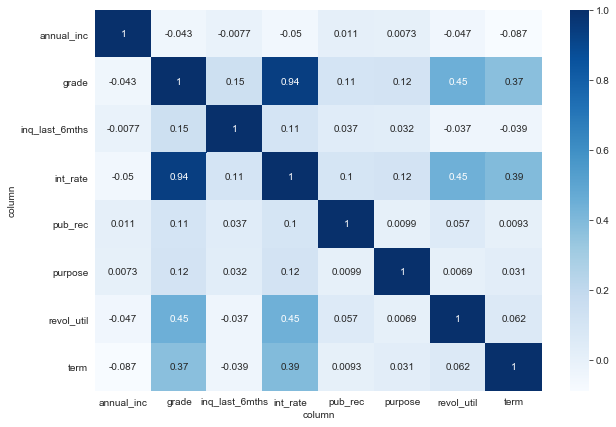

```python
# 观察相关系数热力图
plt.figure(figsize=(10,7))
sns.heatmap(corr, annot=True, cmap='Blues')
```

从热力图上可以看到，grade和int_rate与多个特征值相关性较高，所以将int_rate从特征集合中剔除。

```python
# 剔除相关性高的特征
features_coded.drop(['int_rate'], inplace=True, axis=1)
```

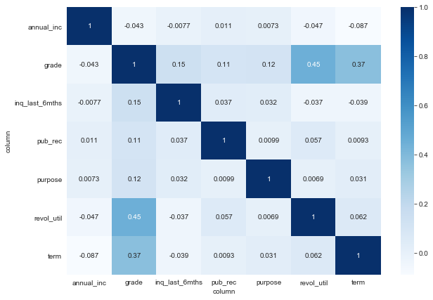

```python
# 计算数值数据的相关系数
corr = features_coded.corr()
plt.figure(figsize=(10,7))
sns.heatmap(corr, annot=True, cmap='Blues')
```

## 3. 机器学习模型构建

### 3.1. 逻辑回归模型

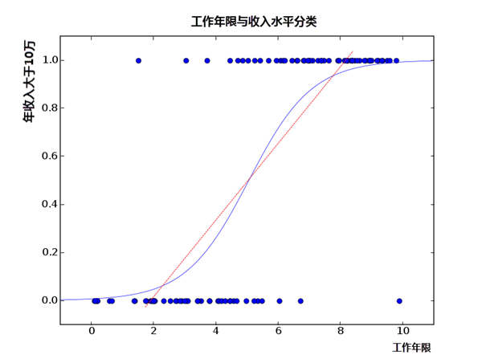

对于典型的二元分类问题，存在预测结果不连续和预测结果有界的特点，传统的线性回归不能很好的解决此类问题。逻辑回归的思路是将线性回归的结果通过逻辑函数映射到（0，1）区间上，从而实现更好的预测结果。经过逻辑函数映射的函数值是样本分类为1的概率。

逻辑函数： $\displaystyle f(x)=\frac{1}{1+e^{-x}}=\frac{e^x}{e^x+1}$

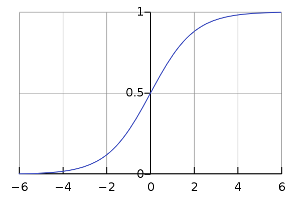

逻辑回归模型的形式： $\displaystyle h_{\theta }(X)=\frac{1}{1+e^{-\theta ^{T}X}}$

其中， $\displaystyle \theta ^T X = \theta_0 + \sum_{i=1}^{n}\theta_iX_i$

将样本分类为1的概率记为p，则 $\displaystyle p = \frac{1}{1+e^{-x}}$

可以推导：$x = \displaystyle log \left(\frac{p}{1-p}\right) = \theta^TX$

逻辑回归算法的拟合过程，是寻找能够使模型预测结果最接近真实分类结果的θ向量。

### 3.2. 模型训练

#### 3.2.1. 训练集和测试集分割

```python
# 模型训练的数据集
features_coded.info()
```

```
<class 'pandas.core.frame.DataFrame'>
RangeIndex: 42535 entries, 0 to 42534
Data columns (total 7 columns):
annual_inc        42535 non-null float64
grade             42535 non-null float64
inq_last_6mths    42535 non-null float64
pub_rec           42535 non-null float64
purpose           42535 non-null float64
revol_util        42535 non-null float64
term              42535 non-null float64
dtypes: float64(7)
memory usage: 2.3 MB
```

```python
# 提取对应的数据标签
labels = data.loc[:, 'loan_status']
labels.head()
```

```
0     Fully Paid
1    Charged Off
2     Fully Paid
3     Fully Paid
4     Fully Paid
Name: loan_status, dtype: object
```

```python
# 将标签值映射为0，1
labels = labels.map({'Fully Paid': 0, 'Charged Off': 1})
labels.head()
```

```
0    0
1    1
2    0
3    0
4    0
Name: loan_status, dtype: int64
```

```python
# 观察违约比例
labels.sum() / len(labels)
```

```
0.1511931350652404
```

```python
from sklearn.model_selection import train_test_split
```

```python
X_train, X_test, y_train, y_test = train_test_split(features_coded, labels, test_size=0.2, random_state=42)
```

#### 3.2.2. 模型训练

```python
from sklearn.linear_model import LogisticRegression
from sklearn.metrics import confusion_matrix
```

```python
# 模型训练
clf = LogisticRegression(class_weight='balanced').fit(X_train, y_train)
```

样本内预测结果：

```python
# 对样本外数据进行预测
y_predict = clf.predict(X_train)
y_predict
```

```
array([1, 1, 1, ..., 0, 1, 1], dtype=int64)
```

```python
# 样本内数据的混淆矩阵
pd.DataFrame(confusion_matrix(y_train, y_predict), columns=['predict_0', 'predict_1'], index=['real_0', 'real_1'])
```

|  | predict_0 | predict_1 |
| --- | --- | --- |
| real_0 | 18234 | 10592 |
| real_1 | 1822 | 3380 |

```python
# 获取训练集数据的预测概率
y_predict_proba = clf.predict_proba(X_train)
```

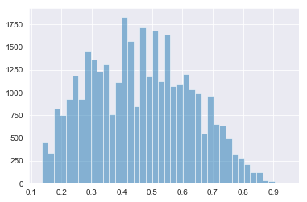

```python
# 观察预测概率的分布情况
plt.hist(y_predict_proba[:,1], bins=40, alpha=0.5)
```

```python
# 观察特征的权重系数
clf.coef_
```

```
array([[-1.45456841, -0.69083162, -0.89455563, -0.6749079 , -0.83730649,
        -0.4583991 , -0.7030131 ]])
```

```python
# 将权重系数与对应特征名称形成表格
coe = pd.DataFrame(clf.coef_.T, index=X_train.columns, columns=['coefficient'])
coe
```

| column | coefficient |
| --- | --- |
| annual_inc | -1.454568 |
| grade | -0.690832 |
| inq_last_6mths | -0.894556 |
| pub_rec | -0.674908 |
| purpose | -0.837306 |
| revol_util | -0.458399 |
| term | -0.703013 |

### 3.3. 模型评估

#### 3.3.1. ROC

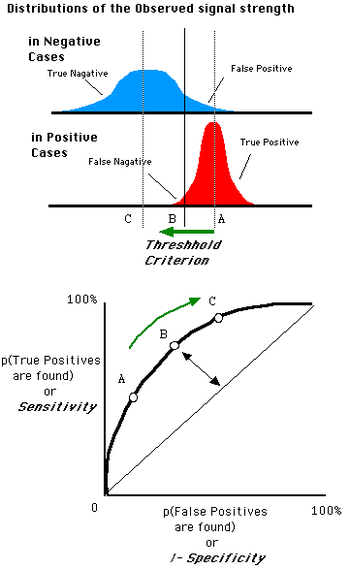

ROC（Reciver Operating Characteristic）：

```python
from sklearn.metrics import roc_curve, auc
```

样本外预测结果：

```python
# 使用模型对样本外数据进行预测
y_predict_test = clf.predict(X_test)
```

```python
# 获得每个样本被分类为1的概率
y_predict_proba = clf.predict_proba(X_test)[:, 1]
y_predict_proba
```

```
array([0.70445441, 0.49438698, 0.45113393, ..., 0.51962791, 0.13495912,
       0.65012215])
```

```python
# 使用 roc_curve() 函数计算不同threshold下的 true_positive 和 false_positive
fpr, tpr, threshold = roc_curve(y_test, y_predict_proba, pos_label=1)
```

```python
# 观察 roc_curve() 函数的计算结果
threshold
```

```
array([0.89798938, 0.89238497, 0.88691753, ..., 0.15316658, 0.15027654,
       0.13495912])
```

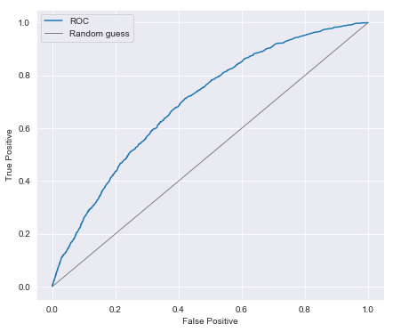

```python
# 绘制 ROC 曲线
plt.figure(figsize=(7, 6))
plt.plot(fpr, tpr)
plt.plot([0, 1],[0, 1], 'grey', linewidth=1)
plt.xlabel('False Positive')
plt.ylabel('True Positive')

plt.legend(['ROC', 'Random guess'])
```

#### 3.3.2. AUC

AUC (Area under Curve)：

- AUC代表ROC曲线与x轴包围的面积
- AUC越大，模型的预测效果越好
- AUC的值一般在0.5到1之间，AUC=0.5说明模型并没有提供有价值的预测(等同于随机猜测）

```python
# 计算 AUC
auc_value = auc(fpr, tpr)
auc_value
```

```
0.6953507578039282
```

#### 3.3.3. KS值

KS曲线与KS值：

- KS曲线是tpr与fpr差值为纵坐标，以分类阈值（threshold）为横坐标形成的曲线
- tpr与fpr差值绝对值的最大值即为KS值，KS值对应的threshold就是模型的最优分类阈值
- KS值可以作为模型效果的判断标准，一般KS值更大的模型有更好的分类效果

```python
# 计算 tpr 与 fpr 差值绝对值的最大值
ks = max(abs(tpr - fpr))
ks
```

```
0.2920653681491821
```

```python
# 找到 KS 值对应的threshold
best_threshold = threshold[np.argmax(abs(tpr - fpr))]
best_threshold
```

```
0.47238323841235713
```

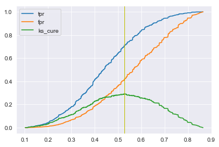

```python
# 生成KS曲线
plt.plot(1 - threshold, tpr)
plt.plot(1 - threshold, fpr)
plt.plot(1 - threshold, tpr - fpr)
plt.axvline(1 - best_threshold, color='y', linewidth=1)
plt.legend(['tpr', 'fpr', 'ks_cure'])
```

## 4. 生成评分卡

逻辑回归模型计算的结果是样本违约的概率，实际操作中为了更方便地根据样本特征对其进行分类，需要将模型计算的违约概率转化为一个容易计算的分值，直接根据样本得分对其进行分类，而不是直接计算违约率。

$ \displaystyle Score = A - B * log\left(\frac{p}{1-p}\right) $

其中： $ \displaystyle log\left(\frac{p}{1-p}\right) = \theta^TX$

$\theta$为逻辑回归模型训练得到的参数组合，$X$为样本的特征向量。

$A,B$ 为函数中的参数，需要通过两个假设条件确定：

- 特定分数与概率的对应关系（特定分值与其对应的概率或比率关系）
- 比率翻番对应的分差（PDO)

一般假设好坏比为30：1的得分为600分，好坏比翻番（PDO, Points to Double Odds）得分增加20分，根据以上条件可以得到：

$600 = A + B * log(30)$

$600 + 20 = A + B * log(60)$

由此可以计算得到：

$ A = 600 - B * log(30)$

$ B = 20 / log(2) $

### 4.1. 构造评分公式

```python
from math import log
```

```python
# 计算评分公式的系数
B = 20 / log(2)
A = 600 - B * log(30)
print(f'A = {A} \nB = {B}')
```

```
A = 501.8621880878296
B = 28.85390081777927
```

```python
# 观察所有样本的woe值
features_coded.head()
```

| column | annual_inc | grade | inq_last_6mths | pub_rec | purpose | revol_util | term |
| --- | --- | --- | --- | --- | --- | --- | --- |
| 0 | -0.347290 | 0.243431 | 0.057323 | 0.040095 | 0.366223 | -0.301714 | 0.239838 |
| 1 | -0.120866 | -0.154333 | -0.624651 | 0.040095 | 0.366223 | 0.412908 | -0.529633 |
| 2 | -0.347290 | -0.154333 | 0.057323 | 0.040095 | -0.763916 | -0.495110 | 0.239838 |
| 3 | -0.120866 | -0.154333 | 0.057323 | 0.040095 | -0.061558 | 0.412908 | 0.239838 |
| 4 | 0.277041 | 0.243431 | 0.057323 | 0.040095 | -0.061558 | -0.063747 | -0.529633 |

```python
# 逻辑回归模型训练得到的特征系数
coe
```

| column | coefficient |
| --- | --- |
| annual_inc | -1.454568 |
| grade | -0.690832 |
| inq_last_6mths | -0.894556 |
| pub_rec | -0.674908 |
| purpose | -0.837306 |
| revol_util | -0.458399 |
| term | -0.703013 |

```python
# 计算所有样本的得分
scores = np.round(A - B * np.dot(features_coded, coe), 0)
scores[:5]
```

```
array([[504.],
       [482.],
       [466.],
       [505.],
       [508.]])
```

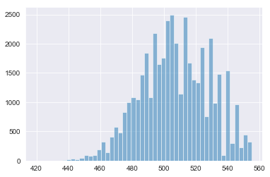

```python
# 得分分布直方图
plt.hist(scores, bins=50, alpha=0.5)
```

### 4.2. 生成评分卡

```python
# 计算每个特征分组的对应分数
group_score = modified_group_map.reset_index(1)
group_score.head(10)
```

| column | group | WoE |
| --- | --- | --- |
| annual_inc | (-inf, 27800.0] | -0.347290 |
| annual_inc | (27800.0, 53800.0] | -0.120866 |
| annual_inc | (53800.0, 79800.0] | 0.033828 |
| annual_inc | (79800.0, 183600.0] | 0.277041 |
| annual_inc | (183600.0, inf] | 0.175411 |
| grade | A | 1.027969 |
| grade | B | 0.243431 |
| grade | C | -0.154333 |
| grade | D | -0.462975 |
| grade | E | -0.680162 |

```python
# 将对应特征的系数填入 group_score 表中
group_score.drop('int_rate', inplace=True)
group_score['coe'] = group_score.index.map(coe.coefficient)
group_score
```

| column | group | WoE | coe |
| --- | --- | --- | --- |
| annual_inc | (-inf, 27800.0] | -0.347290 | -1.454568 |
| annual_inc | (27800.0, 53800.0] | -0.120866 | -1.454568 |
| annual_inc | (53800.0, 79800.0] | 0.033828 | -1.454568 |
| annual_inc | (79800.0, 183600.0] | 0.277041 | -1.454568 |
| annual_inc | (183600.0, inf] | 0.175411 | -1.454568 |
| grade | A | 1.027969 | -0.690832 |
| grade | B | 0.243431 | -0.690832 |
| grade | C | -0.154333 | -0.690832 |
| grade | D | -0.462975 | -0.690832 |
| grade | E | -0.680162 | -0.690832 |
| grade | F | -0.993820 | -0.690832 |
| grade | G | -0.993820 | -0.690832 |
| inq_last_6mths | (-inf, 3.0] | 0.057323 | -0.894556 |
| inq_last_6mths | (3.0, 7.0] | -0.624651 | -0.894556 |
| inq_last_6mths | (7.0, 10.0] | -1.200591 | -0.894556 |
| inq_last_6mths | (10.0, inf] | -1.000378 | -0.894556 |
| pub_rec | 0.0 | 0.040095 | -0.674908 |
| pub_rec | 1.0 | -0.571353 | -0.674908 |
| pub_rec | 2.0 | -0.020526 | -0.674908 |
| pub_rec | 3.0 | -0.020526 | -0.674908 |
| pub_rec | 4.0 | -0.020526 | -0.674908 |
| pub_rec | 5.0 | -0.020526 | -0.674908 |
| purpose | major_purchase | 0.366223 | -0.837306 |
| purpose | car | 0.366223 | -0.837306 |
| purpose | wedding | 0.366223 | -0.837306 |
| purpose | credit_card | 0.366223 | -0.837306 |
| purpose | home_improvement | 0.158848 | -0.837306 |
| purpose | vacation | -0.061558 | -0.837306 |
| purpose | debt_consolidation | -0.061558 | -0.837306 |
| purpose | house | -0.061558 | -0.837306 |
| purpose | medical | -0.061558 | -0.837306 |
| purpose | moving | -0.061558 | -0.837306 |
| purpose | other | -0.061558 | -0.837306 |
| purpose | renewable_energy | -0.266659 | -0.837306 |
| purpose | educational | -0.391469 | -0.837306 |
| purpose | small_business | -0.763916 | -0.837306 |
| revol_util | (-inf, 0.24] | 0.412908 | -0.458399 |
| revol_util | (0.24, 0.48] | 0.139410 | -0.458399 |
| revol_util | (0.48, 0.71] | -0.063747 | -0.458399 |
| revol_util | (0.71, 0.95] | -0.301714 | -0.458399 |
| revol_util | (0.95, inf] | -0.495110 | -0.458399 |
| term | 36 months | 0.239838 | -0.703013 |
| term | 60 months | -0.529633 | -0.703013 |

```python
# 计算每个分组的得分
group_score['score'] = -round(group_score.WoE * group_score.coe * B, 0)
group_score
```

| column | group | WoE | coe | score |
| --- | --- | --- | --- | --- |
| annual_inc | (-inf, 27800.0] | -0.347290 | -1.454568 | -15.0 |
| annual_inc | (27800.0, 53800.0] | -0.120866 | -1.454568 | -5.0 |
| annual_inc | (53800.0, 79800.0] | 0.033828 | -1.454568 | 1.0 |
| annual_inc | (79800.0, 183600.0] | 0.277041 | -1.454568 | 12.0 |
| annual_inc | (183600.0, inf] | 0.175411 | -1.454568 | 7.0 |
| grade | A | 1.027969 | -0.690832 | 20.0 |
| grade | B | 0.243431 | -0.690832 | 5.0 |
| grade | C | -0.154333 | -0.690832 | -3.0 |
| grade | D | -0.462975 | -0.690832 | -9.0 |
| grade | E | -0.680162 | -0.690832 | -14.0 |
| grade | F | -0.993820 | -0.690832 | -20.0 |
| grade | G | -0.993820 | -0.690832 | -20.0 |
| inq_last_6mths | (-inf, 3.0] | 0.057323 | -0.894556 | 1.0 |
| inq_last_6mths | (3.0, 7.0] | -0.624651 | -0.894556 | -16.0 |
| inq_last_6mths | (7.0, 10.0] | -1.200591 | -0.894556 | -31.0 |
| inq_last_6mths | (10.0, inf] | -1.000378 | -0.894556 | -26.0 |
| pub_rec | 0.0 | 0.040095 | -0.674908 | 1.0 |
| pub_rec | 1.0 | -0.571353 | -0.674908 | -11.0 |
| pub_rec | 2.0 | -0.020526 | -0.674908 | -0.0 |
| pub_rec | 3.0 | -0.020526 | -0.674908 | -0.0 |
| pub_rec | 4.0 | -0.020526 | -0.674908 | -0.0 |
| pub_rec | 5.0 | -0.020526 | -0.674908 | -0.0 |
| purpose | major_purchase | 0.366223 | -0.837306 | 9.0 |
| purpose | car | 0.366223 | -0.837306 | 9.0 |
| purpose | wedding | 0.366223 | -0.837306 | 9.0 |
| purpose | credit_card | 0.366223 | -0.837306 | 9.0 |
| purpose | home_improvement | 0.158848 | -0.837306 | 4.0 |
| purpose | vacation | -0.061558 | -0.837306 | -1.0 |
| purpose | debt_consolidation | -0.061558 | -0.837306 | -1.0 |
| purpose | house | -0.061558 | -0.837306 | -1.0 |
| purpose | medical | -0.061558 | -0.837306 | -1.0 |
| purpose | moving | -0.061558 | -0.837306 | -1.0 |
| purpose | other | -0.061558 | -0.837306 | -1.0 |
| purpose | renewable_energy | -0.266659 | -0.837306 | -6.0 |
| purpose | educational | -0.391469 | -0.837306 | -9.0 |
| purpose | small_business | -0.763916 | -0.837306 | -18.0 |
| revol_util | (-inf, 0.24] | 0.412908 | -0.458399 | 5.0 |
| revol_util | (0.24, 0.48] | 0.139410 | -0.458399 | 2.0 |
| revol_util | (0.48, 0.71] | -0.063747 | -0.458399 | -1.0 |
| revol_util | (0.71, 0.95] | -0.301714 | -0.458399 | -4.0 |
| revol_util | (0.95, inf] | -0.495110 | -0.458399 | -7.0 |
| term | 36 months | 0.239838 | -0.703013 | 5.0 |
| term | 60 months | -0.529633 | -0.703013 | -11.0 |

```python
# 生成评分卡
scorecard = group_score[['group', 'score']].set_index('group', append=True)
scorecard
```

| column | group | score |
| --- | --- | --- |
| annual_inc | (-inf, 27800.0] | -15.0 |
|  | (27800.0, 53800.0] | -5.0 |
|  | (53800.0, 79800.0] | 1.0 |
|  | (79800.0, 183600.0] | 12.0 |
|  | (183600.0, inf] | 7.0 |
| grade | A | 20.0 |
|  | B | 5.0 |
|  | C | -3.0 |
|  | D | -9.0 |
|  | E | -14.0 |
|  | F | -20.0 |
|  | G | -20.0 |
| inq_last_6mths | (-inf, 3.0] | 1.0 |
|  | (3.0, 7.0] | -16.0 |
|  | (7.0, 10.0] | -31.0 |
|  | (10.0, inf] | -26.0 |
| pub_rec | 0.0 | 1.0 |
|  | 1.0 | -11.0 |
|  | 2.0 | -0.0 |
|  | 3.0 | -0.0 |
|  | 4.0 | -0.0 |
|  | 5.0 | -0.0 |
| purpose | major_purchase | 9.0 |
|  | car | 9.0 |
|  | wedding | 9.0 |
|  | credit_card | 9.0 |
|  | home_improvement | 4.0 |
|  | vacation | -1.0 |
|  | debt_consolidation | -1.0 |
|  | house | -1.0 |
|  | medical | -1.0 |
|  | moving | -1.0 |
|  | other | -1.0 |
|  | renewable_energy | -6.0 |
|  | educational | -9.0 |
|  | small_business | -18.0 |
| revol_util | (-inf, 0.24] | 5.0 |
|  | (0.24, 0.48] | 2.0 |
|  | (0.48, 0.71] | -1.0 |
|  | (0.71, 0.95] | -4.0 |
|  | (0.95, inf] | -7.0 |
| term | 36 months | 5.0 |
|  | 60 months | -11.0 |